# Additional Coding: Update #6

```r
set.seed(1612201348)
bp85_10Sim <- sim_NPlay(keyFrame=bp85_10Play$out10Play, useName="BP 85",
                        nPlay=10, nHands=16000, nSim=2000
                        )
```

```
##
## Mean return per hand: 0.9916439 with total variance: 399.5
## Mean return per hand: 99.174% with total variance (sd as % of total bet): 6,170,846 ( 1.55% )
##      1%      5%     10%     25%     50%     75%     90%     95%     99%
## -0.0364 -0.0303 -0.0263 -0.0186 -0.0096 -0.0001  0.0106  0.0188  0.0454
```

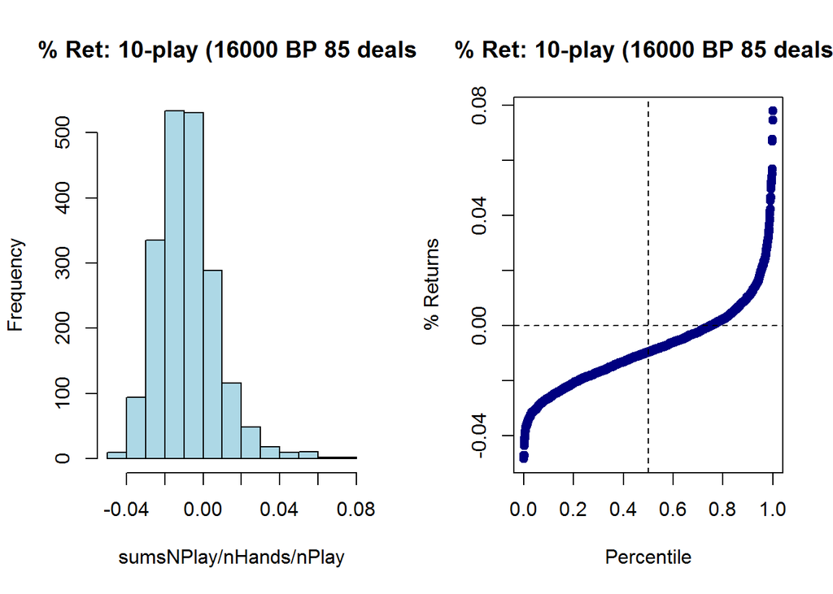

```r
set.seed(1612211338)
bp85_5Sim <- sim_NPlay(keyFrame=bp85_5Play$dfOutcome, useName="BP 85",
                       nPlay=5, nHands=16000, nSim=2000
                       )
```

```
##
## Mean return per hand: 0.9916568 with total variance: 146.9033
## Mean return per hand: 99.13% with total variance (sd as % of total bet): 2,500,141 ( 1.98% )
##      1%      5%     10%     25%     50%     75%     90%     95%     99%
## -0.0447 -0.0359 -0.0311 -0.0228 -0.0108  0.0023  0.0174  0.0269  0.0479
```

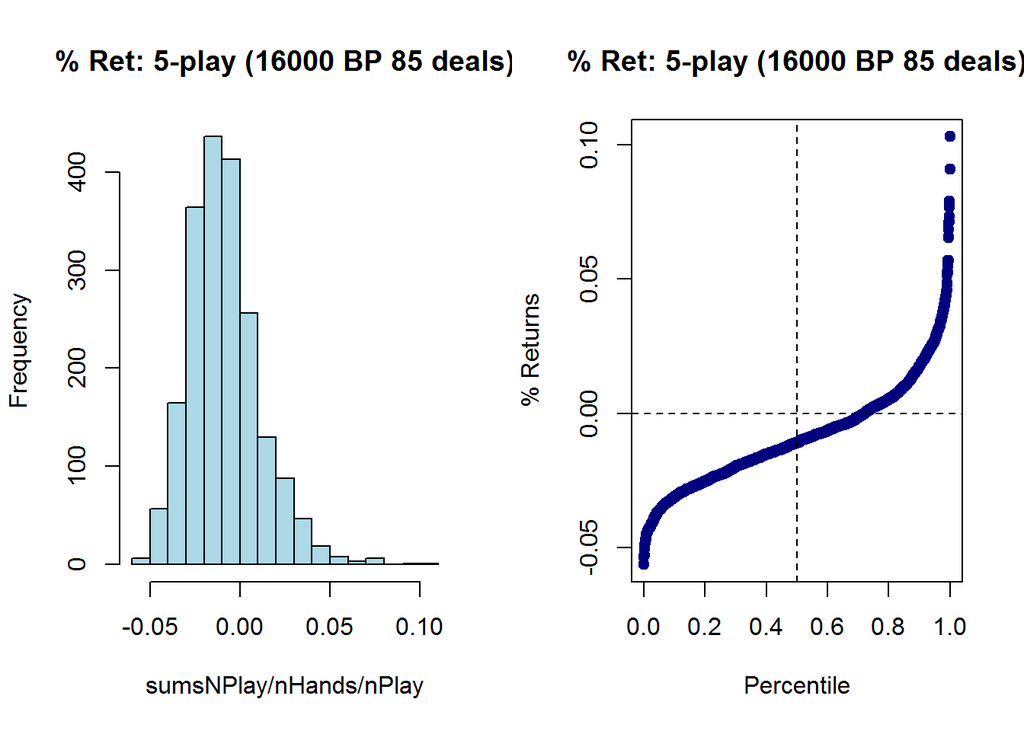

```r
set.seed(2016122008)
bpd96_10Sim <- sim_NPlay(keyFrame=bpd96_10Play$out10Play, useName="BPD 96",
                         nPlay=10, nHands=16000, nSim=2000
                         )
```

```
##
## Mean return per hand: 0.996406 with total variance: 652.7752
## Mean return per hand: 99.563% with total variance (sd as % of total bet): 10,255,554 ( 2% )
##      1%      5%     10%     25%     50%     75%     90%     95%     99%
## -0.0477 -0.0361 -0.0291 -0.0175 -0.0054  0.0080  0.0203  0.0292  0.0498
```

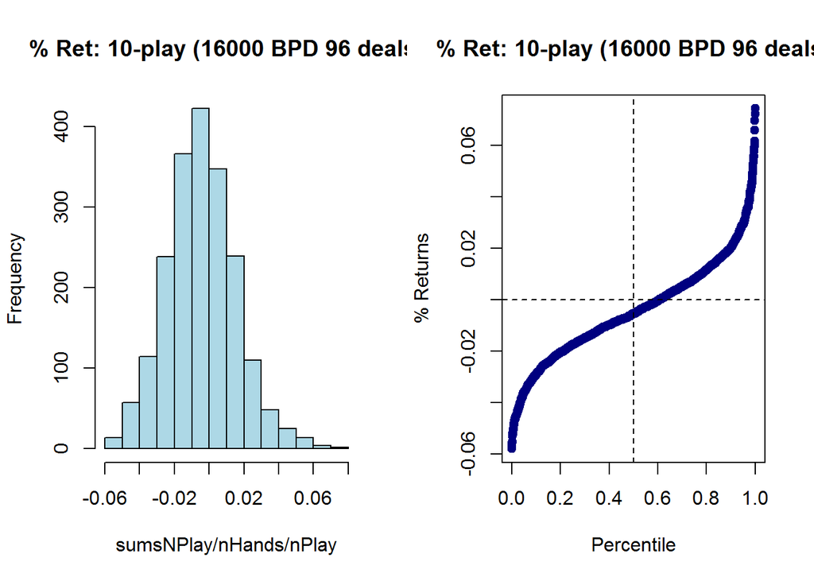

```r
set.seed(2016122108)
bpd96_5Sim <- sim_NPlay(keyFrame=bpd96_5Play$dfOutcome, useName="BPD 96",
                        nPlay=5, nHands=16000, nSim=2000
                        )
```

```
##
## Mean return per hand: 0.9964151 with total variance: 234.3575
## Mean return per hand: 99.652% with total variance (sd as % of total bet): 3,584,023 ( 2.37% )
##      1%      5%     10%     25%     50%     75%     90%     95%     99%
## -0.0517 -0.0405 -0.0327 -0.0203 -0.0045  0.0116  0.0272  0.0374  0.0593
```

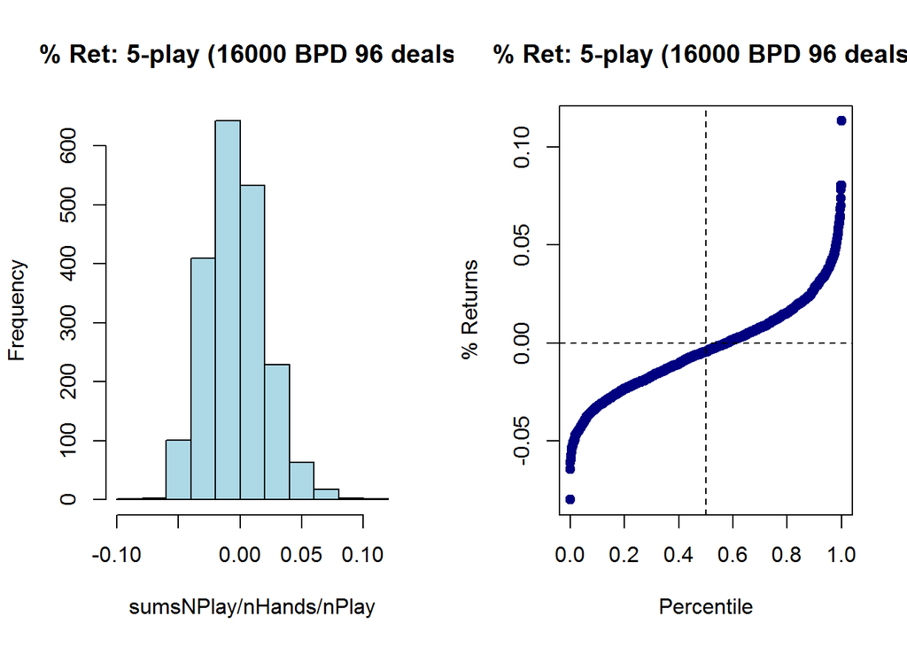

```r
set.seed(1220160749)
ddb96_10Sim <- sim_NPlay(keyFrame=ddb96_10Play$out10Play, useName="DDB 96",
                         nPlay=10, nHands=16000, nSim=2000
                         )
```

```
##
## Mean return per hand: 0.9897956 with total variance: 852.4156
## Mean return per hand: 98.896% with total variance (sd as % of total bet): 12,411,898 ( 2.2% )
##      1%      5%     10%     25%     50%     75%     90%     95%     99%
## -0.0578 -0.0449 -0.0382 -0.0269 -0.0116  0.0031  0.0173  0.0272  0.0446
```

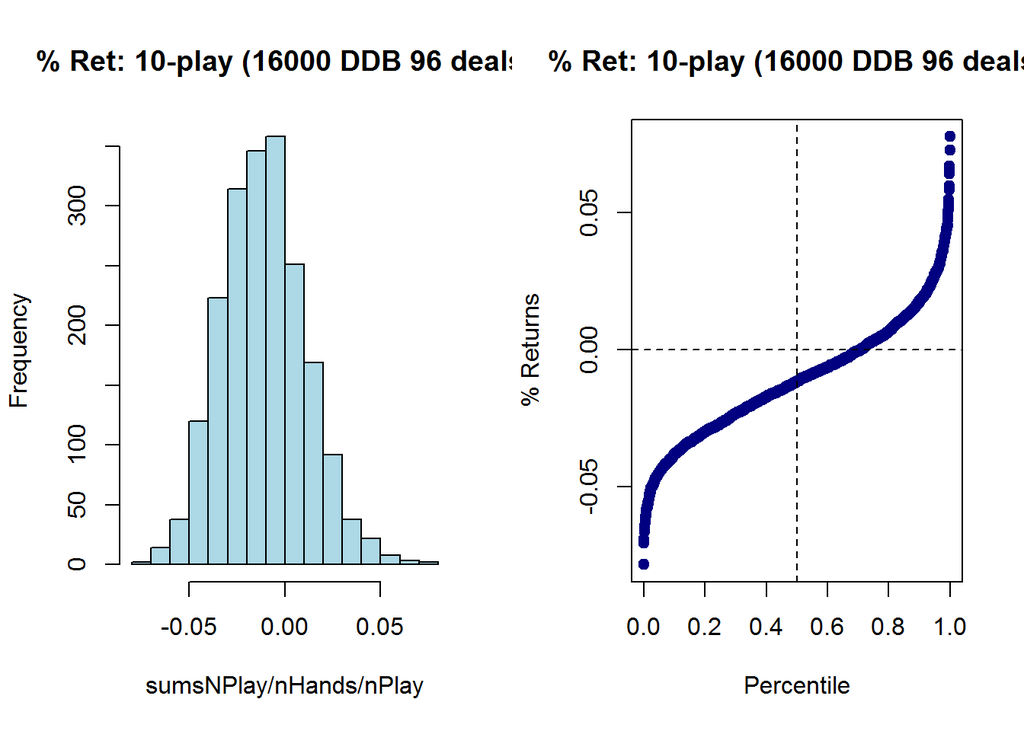

```r
set.seed(1221160739)
ddb96_5Sim <- sim_NPlay(keyFrame=ddb96_5Play$dfOutcome, useName="DDB 96",
                        nPlay=5, nHands=16000, nSim=2000
                        )
```

```
##
## Mean return per hand: 0.9898018 with total variance: 306.0667
## Mean return per hand: 98.942% with total variance (sd as % of total bet): 4,671,484 ( 2.7% )
##      1%      5%     10%     25%     50%     75%     90%     95%     99%
## -0.0655 -0.0523 -0.0443 -0.0294 -0.0123  0.0069  0.0243  0.0352  0.0626
```

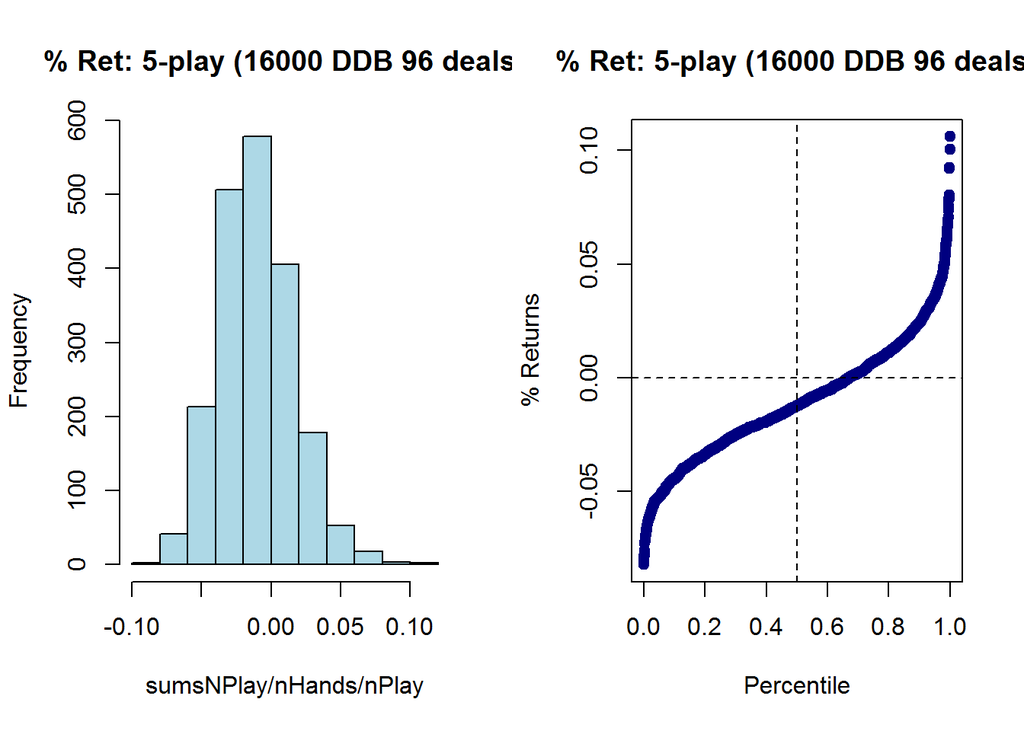

```r
set.seed(1220201608)
tdb96_10Sim <- sim_NPlay(keyFrame=tdb96_10Play$out10Play, useName="TDB 96",
                         nPlay=10, nHands=16000, nSim=2000
                         )
```

```
##
## Mean return per hand: 0.9815219 with total variance: 1961.747
## Mean return per hand: 98.154% with total variance (sd as % of total bet): 31,748,125 ( 3.52% )
##      1%      5%     10%     25%     50%     75%     90%     95%     99%
## -0.0905 -0.0723 -0.0619 -0.0427 -0.0207  0.0031  0.0276  0.0436  0.0792
```

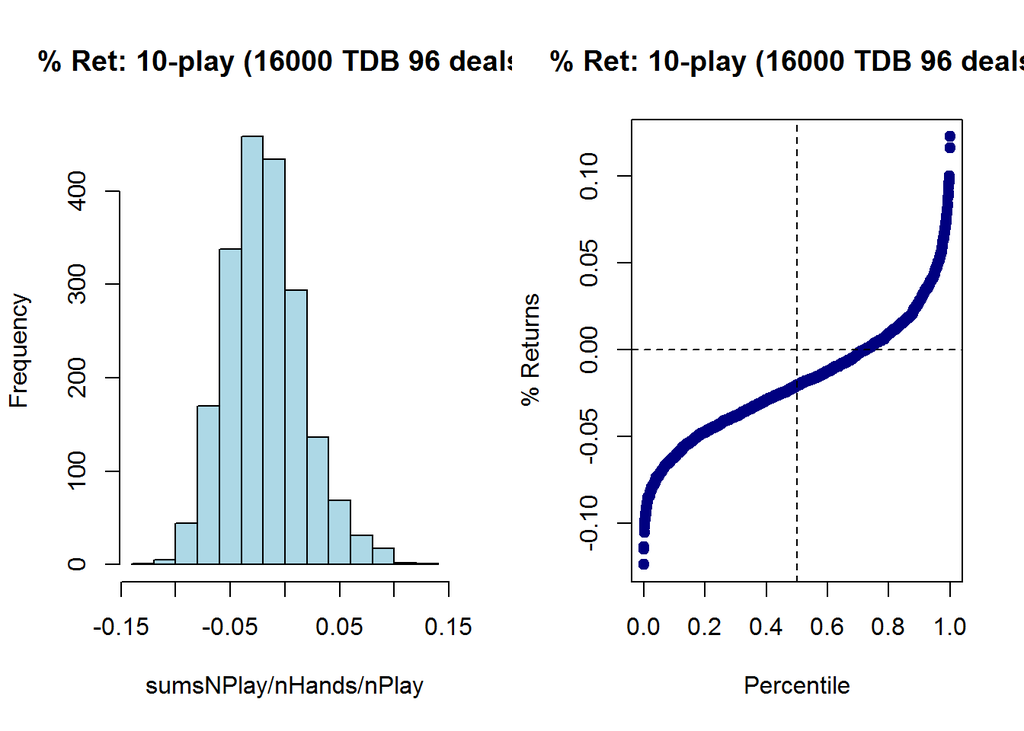

```r
set.seed(1221201608)
tdb96_5Sim <- sim_NPlay(keyFrame=tdb96_5Play$dfOutcome, useName="TDB 96",
                        nPlay=5, nHands=16000, nSim=2000
                        )
```

```
##
## Mean return per hand: 0.9815355 with total variance: 714.0964
## Mean return per hand: 98.241% with total variance (sd as % of total bet): 11,199,067 ( 4.18% )
##      1%      5%     10%     25%     50%     75%     90%     95%     99%
## -0.1028 -0.0822 -0.0686 -0.0472 -0.0208  0.0097  0.0362  0.0547  0.0883
```

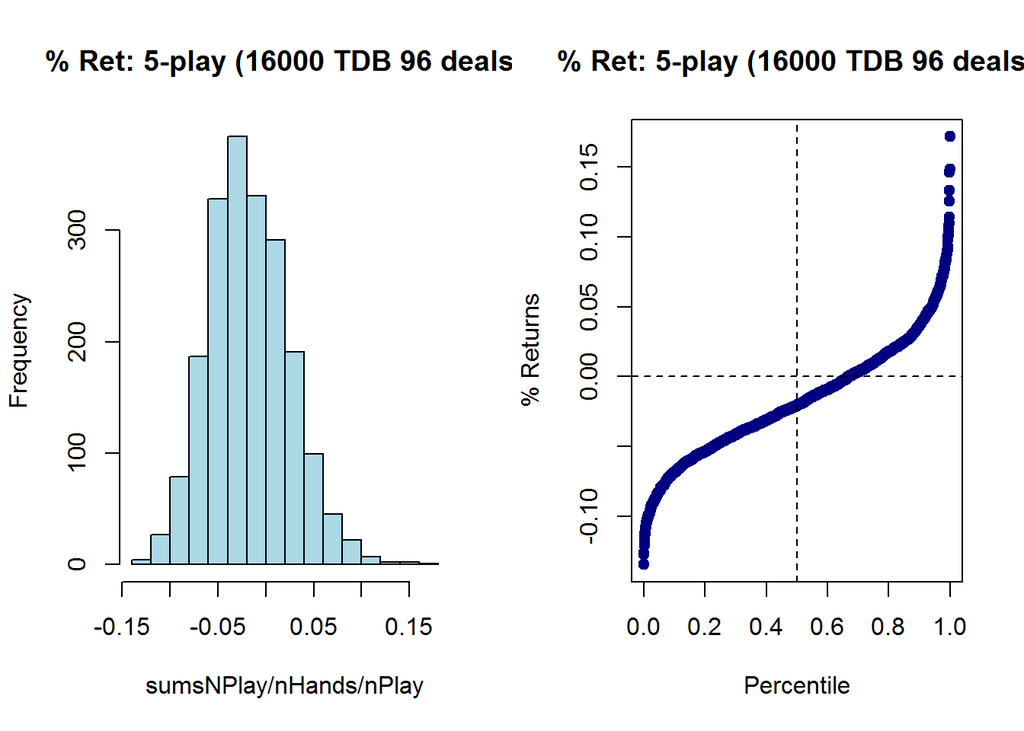

A second attempt is made to further vectorize the n-play process, with results compared to the previous results:

```r
# Function to create the 1-play data
get_uq1Play <- function(keyList) {

    # Get the basic parameters
    uq_1PlayRes <- keyList$mapOuts
    uqCol <- ncol(keyList$uqCards)
    cWeight <- keyList$uqCards[, uqCol]
    uqHands <- keyList$uqCards[, -uqCol]

    # Convert uqHands to percentage outcomes by hand
    uq_1Play <- diag(1/rowSums(uqHands)) %*% uqHands
    str(uq_1Play)
    table(rowSums(uq_1Play))

    list(uq_Play=uq_1Play, uq_Res=uq_1PlayRes, cWeight=cWeight)

}


# Get the 1-play data for JB 96, BP 85, and TDB 96
startTime <- proc.time()

jb96_uq001 <- get_uq1Play(keyList=jb96UniqueList)
```

```
##  num [1:1279, 1:10] 0 0 0 0 0.702 ...
##  - attr(*, "dimnames")=List of 2
##   ..$ : NULL
##   ..$ : chr [1:10] "" "" "" "" ...
```

```r
str(jb96_uq001)
```

```
## List of 3
##  $ uq_Play: num [1:1279, 1:10] 0 0 0 0 0.702 ...
##   ..- attr(*, "dimnames")=List of 2
##   .. ..$ : NULL
##   .. ..$ : chr [1:10] "" "" "" "" ...
##  $ uq_Res : num [1:10] -1 799 49 8 5 3 2 1 0 24
##  $ cWeight: Named num [1:1279] 624 3744 54912 123552 96 ...
##   ..- attr(*, "names")= chr [1:1279] "1" "2" "3" "4" ...
```

```r
bp85_uq001 <- get_uq1Play(keyList=bp85UniqueList)
```

```
##  num [1:1647, 1:12] 0 0 0 0 0 ...
##  - attr(*, "dimnames")=List of 2
##   ..$ : NULL
##   ..$ : chr [1:12] "" "" "" "" ...
```

```r
str(bp85_uq001)
```

```
## List of 3
##  $ uq_Play: num [1:1647, 1:12] 0 0 0 0 0 ...
##   ..- attr(*, "dimnames")=List of 2
##   .. ..$ : NULL
##   .. ..$ : chr [1:12] "" "" "" "" ...
##  $ uq_Res : num [1:12] -1 799 49 7 4 3 2 1 0 79 ...
##  $ cWeight: Named num [1:1647] 48 144 432 3744 4224 ...
##   ..- attr(*, "names")= chr [1:1647] "1" "2" "3" "4" ...
```

```r
tdb96_uq001 <- get_uq1Play(keyList=tdb96UniqueList)
```

```
##  num [1:945, 1:11] 0 0 0 0 0 0 0 0 0 0 ...
##  - attr(*, "dimnames")=List of 2
##   ..$ : NULL
##   ..$ : chr [1:11] "" "" "" "" ...
```

```r
str(tdb96_uq001)
```

```
## List of 3
##  $ uq_Play: num [1:945, 1:11] 0 0 0 0 0 0 0 0 0 0 ...
##   ..- attr(*, "dimnames")=List of 2
##   .. ..$ : NULL
##   .. ..$ : chr [1:11] "" "" "" "" ...
##  $ uq_Res : num [1:11] -1 799 49 8 5 3 1 0 159 399 ...
##  $ cWeight: Named num [1:945] 16 36 36 108 468 ...
##   ..- attr(*, "names")= chr [1:945] "1" "2" "3" "4" ...
```

```r
proc.time() - startTime
```

```
##    user  system elapsed
##    0.09    0.00    0.10
```

```r
# Function to cross-product n-play and m-play
create_mnPlay <- function(keyN, keyM) {

    aTest <- matrix(data=0, nrow=nrow(keyN$uq_Play),
                    ncol=ncol(keyM$uq_Play)*ncol(keyN$uq_Play)
                    )

    # Matrix multiply by "flavor" (unique rows)
    for (intCtr in 1:nrow(keyN$uq_Play)) {
        aTest[intCtr, ] <- as.vector( outer( keyN$uq_Play[intCtr, ], keyM$uq_Play[intCtr, ] ) )
    }

    # Sum outcomes for matrix cross product (column values for aTest)
    aScore <- as.vector(outer(keyN$uq_Res, keyM$uq_Res, FUN="+"))

    # Find and sort the unique scores
    uqRes <- sort(unique(aScore))

    # Convert the full aTest in to unique hands with values by column
    map_Play <- matrix(data=0L, nrow=ncol(aTest), ncol=length(uqRes))
    map_Mtx <- matrix(data=c(1:length(aScore), match(aScore, uqRes)),
                      nrow=length(aScore)
                      )
    map_Play[ map_Mtx ] <- 1L
    uq_Play <- aTest %*% map_Play

    list(uq_Play=uq_Play, uq_Res=uqRes, cWeight=keyN$cWeight)

}


# Take JB 96, BP 85, and TDB 96 and expand from 1-play to 2-5 play
startTime <- proc.time()

jb96_uq002 <- create_mnPlay(keyN=jb96_uq001, keyM=jb96_uq001)
jb96_uq003 <- create_mnPlay(keyN=jb96_uq002, keyM=jb96_uq001)
jb96_uq004 <- create_mnPlay(keyN=jb96_uq003, keyM=jb96_uq001)
jb96_uq005 <- create_mnPlay(keyN=jb96_uq004, keyM=jb96_uq001)

proc.time() - startTime
```

```
##    user  system elapsed
##    1.61    0.01    1.63
```

```r
bp85_uq002 <- create_mnPlay(keyN=bp85_uq001, keyM=bp85_uq001)
bp85_uq003 <- create_mnPlay(keyN=bp85_uq002, keyM=bp85_uq001)
bp85_uq004 <- create_mnPlay(keyN=bp85_uq003, keyM=bp85_uq001)
bp85_uq005 <- create_mnPlay(keyN=bp85_uq004, keyM=bp85_uq001)

proc.time() - startTime
```

```
##    user  system elapsed
##    9.78    0.08    9.99
```

```r
tdb96_uq002 <- create_mnPlay(keyN=tdb96_uq001, keyM=tdb96_uq001)
tdb96_uq003 <- create_mnPlay(keyN=tdb96_uq002, keyM=tdb96_uq001)
tdb96_uq004 <- create_mnPlay(keyN=tdb96_uq003, keyM=tdb96_uq001)
tdb96_uq005 <- create_mnPlay(keyN=tdb96_uq004, keyM=tdb96_uq001)

proc.time() - startTime
```

```
##    user  system elapsed
##   16.05    0.08   16.34
```

The comparisons to former algorithms are cached to improve run times:

```r
# Compare with the former algorithm (JB 96)
new_2dfOutcome <- data.frame(nOutcome=jb96_uq002$uq_Res,
                             wts=colSums(diag(jb96_uq002$cWeight) %*% jb96_uq002$uq_Play)
                             )
new_5dfOutcome <- data.frame(nOutcome=jb96_uq005$uq_Res,
                             wts=colSums(diag(jb96_uq005$cWeight) %*% jb96_uq005$uq_Play)
                             )

jb96_2Play <- assessNPlay(keyList=jb96UniqueList, nPlay=2L)
```

```
## List of 2
##  $ : int [1:100] 1 1 1 1 1 1 1 1 1 1 ...
##  $ : int [1:100] 1 2 3 4 5 6 7 8 9 10 ...
##
##    1
## 1279
##  int [1:100, 1:2] 1 1 1 1 1 1 1 1 1 1 ...
##      [,1] [,2]
## [1,]    1    1
## [2,]    1    2
## [3,]    1    3
## [4,]    1    4
## [5,]    1    5
## [6,]    1    6
##
##
## Number of unique outcome types: 42
##
## Moving to assess the: 42 rows of outcomes
##
##
## Mean: 0.995439       Variance: 42.96213
```

```r
jb96_5Play <- assessNPlay(keyList=jb96UniqueList, nPlay=5L)
```

```
## List of 5
##  $ : int [1:100000] 1 1 1 1 1 1 1 1 1 1 ...
##  $ : int [1:100000] 1 1 1 1 1 1 1 1 1 1 ...
##  $ : int [1:100000] 1 1 1 1 1 1 1 1 1 1 ...
##  $ : int [1:100000] 1 1 1 1 1 1 1 1 1 1 ...
##  $ : int [1:100000] 1 2 3 4 5 6 7 8 9 10 ...
##
##    1
## 1279
##  int [1:100000, 1:5] 1 1 1 1 1 1 1 1 1 1 ...
##      [,1] [,2] [,3] [,4] [,5]
## [1,]    1    1    1    1    1
## [2,]    1    1    1    1    2
## [3,]    1    1    1    1    3
## [4,]    1    1    1    1    4
## [5,]    1    1    1    1    5
## [6,]    1    1    1    1    6
##
##
## Number of unique outcome types: 406
##
## Moving to assess the: 406 rows of outcomes
##  num [1:1279, 1:45] 0 0 0 0 0.000157 ...
##  num [1:1279] 0 0 0 0 0.00157 ...
## [1] 100
##  num [1:1279, 1:280] 0 0 0 0 0 0 0 0 0 0 ...
##  num [1:1279] 0 0 0 0 0 0 0 0 0 0 ...
## [1] 200
##  num [1:1279, 1:240] 0 0 0 0 0 ...
##  num [1:1279] 0 0 0 0 0 ...
## [1] 300
##  num [1:1279, 1:5] 0 0 0 0 0 0 0 0 0 0 ...
##  num [1:1279] 0 0 0 0 0 0 0 0 0 0 ...
## [1] 400
##
##
## Mean: 0.995439       Variance: 136.9012
```

```r
all.equal(as.data.frame(jb96_2Play$dfOutcome[, -2]), new_2dfOutcome)
```

```
## [1] TRUE
```

```r
all.equal(as.data.frame(jb96_5Play$dfOutcome[, -2]), new_5dfOutcome)
```

```
## [1] TRUE
```

```r
# Compare with the former algorithm (BP 85)
new_2dfOutcome <- data.frame(nOutcome=bp85_uq002$uq_Res,
                             wts=colSums(diag(bp85_uq002$cWeight) %*% bp85_uq002$uq_Play)
                             )
new_5dfOutcome <- data.frame(nOutcome=bp85_uq005$uq_Res,
                             wts=colSums(diag(bp85_uq005$cWeight) %*% bp85_uq005$uq_Play)
                             )

bp85_2Play <- assessNPlay(keyList=bp85UniqueList, nPlay=2L)
```

```
## List of 2
##  $ : int [1:144] 1 1 1 1 1 1 1 1 1 1 ...
##  $ : int [1:144] 1 2 3 4 5 6 7 8 9 10 ...
##
##    1
## 1647
##  int [1:144, 1:2] 1 1 1 1 1 1 1 1 1 1 ...
##      [,1] [,2]
## [1,]    1    1
## [2,]    1    2
## [3,]    1    3
## [4,]    1    4
## [5,]    1    5
## [6,]    1    6
##
##
## Number of unique outcome types: 63
##
## Moving to assess the: 63 rows of outcomes
##
##
## Mean: 0.9916597      Variance: 46.04822
```

```r
bp85_5Play <- assessNPlay(keyList=bp85UniqueList, nPlay=5L)
```

```
## List of 5
##  $ : int [1:248832] 1 1 1 1 1 1 1 1 1 1 ...
##  $ : int [1:248832] 1 1 1 1 1 1 1 1 1 1 ...
##  $ : int [1:248832] 1 1 1 1 1 1 1 1 1 1 ...
##  $ : int [1:248832] 1 1 1 1 1 1 1 1 1 1 ...
##  $ : int [1:248832] 1 2 3 4 5 6 7 8 9 10 ...
##
##    1
## 1647
##  int [1:248832, 1:5] 1 1 1 1 1 1 1 1 1 1 ...
##      [,1] [,2] [,3] [,4] [,5]
## [1,]    1    1    1    1    1
## [2,]    1    1    1    1    2
## [3,]    1    1    1    1    3
## [4,]    1    1    1    1    4
## [5,]    1    1    1    1    5
## [6,]    1    1    1    1    6
##
##
## Number of unique outcome types: 722
##
## Moving to assess the: 722 rows of outcomes
##  num [1:1647, 1:1230] 0 0 0 0 0 0 0 0 0 0 ...
##  num [1:1647] 0 0 0 0 0 ...
## [1] 100
##  num [1:1647, 1:120] 0 0 0 0 0 0 0 0 0 0 ...
##  num [1:1647] 0 0 0 0 0 0 0 0 0 0 ...
## [1] 200
##  num [1:1647, 1:5] 0 0 0 0 0 0 0 0 0 0 ...
##  num [1:1647] 0 0 0 0 0 0 0 0 0 0 ...
## [1] 300
##  num [1:1647, 1:420] 0 0 0 0 0 0 0 0 0 0 ...
##  num [1:1647] 0 0 0 0 0 0 0 0 0 0 ...
## [1] 400
##  num [1:1647, 1:60] 0 0 0 0 0 0 0 0 0 0 ...
##  num [1:1647] 0 0 0 0 0 0 0 0 0 0 ...
## [1] 500
##  num [1:1647, 1:120] 0 0 0 0 0 0 0 0 0 0 ...
##  num [1:1647] 0 0 0 0 0 0 0 0 0 0 ...
## [1] 600
##  num [1:1647, 1:20] 0 0 0 0 0 0 0 0 0 0 ...
##  num [1:1647] 0 0 0 0 0 0 0 0 0 0 ...
## [1] 700
##
##
## Mean: 0.9916597      Variance: 146.9209
```

```r
all.equal(as.data.frame(bp85_2Play$dfOutcome[, -2]), new_2dfOutcome)
```

```
## [1] TRUE
```

```r
all.equal(as.data.frame(bp85_5Play$dfOutcome[, -2]), new_5dfOutcome)
```

```
## [1] TRUE
```

```r
# Compare with the former algorithm (TDB 96)
new_2dfOutcome <- data.frame(nOutcome=tdb96_uq002$uq_Res,
                             wts=colSums(diag(tdb96_uq002$cWeight) %*% tdb96_uq002$uq_Play)
                             )
new_5dfOutcome <- data.frame(nOutcome=tdb96_uq005$uq_Res,
                             wts=colSums(diag(tdb96_uq005$cWeight) %*% tdb96_uq005$uq_Play)
                             )

tdb96_2Play <- assessNPlay(keyList=tdb96UniqueList, nPlay=2L)
```

```
## List of 2
##  $ : int [1:121] 1 1 1 1 1 1 1 1 1 1 ...
##  $ : int [1:121] 1 2 3 4 5 6 7 8 9 10 ...
##
##   1
## 945
##  int [1:121, 1:2] 1 1 1 1 1 1 1 1 1 1 ...
##      [,1] [,2]
## [1,]    1    1
## [2,]    1    2
## [3,]    1    3
## [4,]    1    4
## [5,]    1    5
## [6,]    1    6
##
##
## Number of unique outcome types: 59
##
## Moving to assess the: 59 rows of outcomes
##
##
## Mean: 0.98154        Variance: 221.5844
```

```r
tdb96_5Play <- assessNPlay(keyList=tdb96UniqueList, nPlay=5L)
```

```
## List of 5
##  $ : int [1:161051] 1 1 1 1 1 1 1 1 1 1 ...
##  $ : int [1:161051] 1 1 1 1 1 1 1 1 1 1 ...
##  $ : int [1:161051] 1 1 1 1 1 1 1 1 1 1 ...
##  $ : int [1:161051] 1 1 1 1 1 1 1 1 1 1 ...
##  $ : int [1:161051] 1 2 3 4 5 6 7 8 9 10 ...
##
##   1
## 945
##  int [1:161051, 1:5] 1 1 1 1 1 1 1 1 1 1 ...
##      [,1] [,2] [,3] [,4] [,5]
## [1,]    1    1    1    1    1
## [2,]    1    1    1    1    2
## [3,]    1    1    1    1    3
## [4,]    1    1    1    1    4
## [5,]    1    1    1    1    5
## [6,]    1    1    1    1    6
##
##
## Number of unique outcome types: 1064
##
## Moving to assess the: 1064 rows of outcomes
##  num [1:945, 1:220] 0 0 0 0 0 0 0 0 0 0 ...
##  num [1:945] 0 0 0 0 0 0 0 0 0 0 ...
## [1] 100
##  num [1:945, 1:390] 0 0 0 0 0 0 0 0 0 0 ...
##  num [1:945] 0 0 0 0 0 0 0 0 0 0 ...
## [1] 200
##  num [1:945, 1:90] 0 0 0 0 0 0 0 0 0 0 ...
##  num [1:945] 0 0 0 0 0 0 0 0 0 0 ...
## [1] 300
##  num [1:945, 1:90] 0 0 0 0 0 0 0 0 0 0 ...
##  num [1:945] 0 0 0 0 0 ...
## [1] 400
##  num [1:945, 1:60] 0 0 0 0 0 0 0 0 0 0 ...
##  num [1:945] 0 0 0 0 0 0 0 0 0 0 ...
## [1] 500
##  num [1:945, 1:290] 0 0 0 0 0 0 0 0 0 0 ...
##  num [1:945] 0 0 0 0 0 ...
## [1] 600
##  num [1:945, 1:200] 0 0 0 0 0 0 0 0 0 0 ...
##  num [1:945] 0 0 0 0 0 0 0 0 0 0 ...
## [1] 700
##  num [1:945, 1:180] 0 0 0 0 0 0 0 0 0 0 ...
##  num [1:945] 0 0 0 0 0 0 0 0 0 0 ...
## [1] 800
##  num [1:945, 1:115] 0 0 0 0 0 0 0 0 0 0 ...
##  num [1:945] 0 0 0 0.0158 0 ...
## [1] 900
##  num [1:945, 1:60] 0 0 0 0 0 0 0 0 0 0 ...
##  num [1:945] 0 0 0 0 0 0 0 0 0 0 ...
## [1] 1000
##
##
## Mean: 0.98154        Variance: 714.1226
```

```r
all.equal(as.data.frame(tdb96_2Play$dfOutcome[, -2]), new_2dfOutcome)
```

```
## [1] TRUE
```

```r
all.equal(as.data.frame(tdb96_5Play$dfOutcome[, -2]), new_5dfOutcome)
```

```
## [1] TRUE
```

So, the algorithm is a quicker way for expanding n-Play for reasonably small values of n (in the ~5 range) that preserve the “by outcome flavor” nature of the matrix.

Additionally, an algorithm is written to simplify away flavors that have a very low probability of occuring. For example, while it is theoretically possible to get 4 RF and 1 4 AwaK by holding a naked Ace, the probabilities of this occuring are vanishingly small. Because the matrices propagate forward, this very improbable outcome can then be combined with getting an A-5 SF, 4 2/3/4wA, and the like. The upshot is a lot of clutter in the matrices (straining memory and run-time) with no pragmatic impact on mean and variance.

As a default, an outcome (N-play flavor) is considered to be extremely unlikely if it would be observed less that once ever 25 billion dealt hands (10,000 cycles), though this tolerance can be adjusted. These probabilities can either be ignored (all other probabilities scaled up accordingly), placed in their own column with the appropriate mean, or allocated to existing columns nearest to them.

```r
clean_NPlay <- function(nPlayInput, nTol=0.0001, reAlloc=TRUE, makeOwn=TRUE) {

    # Anything with occurence less than nTol per choose(52, 5) will be excluded from the output
    # If reAlloc==TRUE then all other elements are scaled up to get total back to choose(52, 5)
    # If reAlloc==FALSE and makeOwn==TRUE, all exclusions are aggregated a single "new" column
    # If reAlloc==FALSE and makeOwn==FALSE, all exclusions are re-assigned to the closest column

    cWeight <- nPlayInput$cWeight
    uq_Play <- nPlayInput$uq_Play
    uq_Res <- nPlayInput$uq_Res

    colWts <- colSums( cWeight * uq_Play )
    tooSmall <- (colWts < nTol)

    # Grab the contributions tomean and variance for tooSmall, !tooSmall, and all
    fullSum <- sum(colWts * uq_Res)
    lrgSum <- sum(colWts[!tooSmall] * uq_Res[!tooSmall])
    smlSum <- sum(colWts[tooSmall] * uq_Res[tooSmall])

    fullSum2 <- sum(colWts * uq_Res^2)
    lrgSum2 <- sum(colWts[!tooSmall] * uq_Res[!tooSmall]^2)
    smlSum2 <- sum(colWts[tooSmall] * uq_Res[tooSmall]^2)


    cat("\n\nContributions to SUM:",
        prettyNum(round(fullSum, 1), big.mark=","),
        prettyNum(round(lrgSum, 1), big.mark=","),
        paste0("(", round(100*lrgSum/fullSum, 2), "%)"),
        prettyNum(round(smlSum, 1), big.mark=","),
        paste0("(", round(100*smlSum/fullSum, 2), "%)")
        )

    cat("\nContributions to SUM-SQUARED:",
        prettyNum(round(fullSum2, 0), big.mark=","),
        prettyNum(round(lrgSum2, 0), big.mark=","),
        paste0("(", round(100*lrgSum2/fullSum2, 2), "%)"),
        prettyNum(round(smlSum2, 0), big.mark=","),
        paste0("(", round(100*smlSum2/fullSum2, 2), "%)")
        )

    cat("\n\nMeans Assuming All, Large, Small:",
        round(fullSum/sum(colWts), 6),
        round(lrgSum/sum(colWts[!tooSmall]), 6),
        round(smlSum/sum(colWts[tooSmall]), 6)
        )

    cat("\nVariances Assuming All, Large, Small:",
        prettyNum(fullSum2/sum(colWts) - (fullSum/sum(colWts))^2, big.mark=","),
        prettyNum(lrgSum2/sum(colWts[!tooSmall]) - (lrgSum/sum(colWts[!tooSmall]))^2, big.mark=","),
        prettyNum(smlSum2/sum(colWts[tooSmall]) - (smlSum/sum(colWts[tooSmall]))^2, big.mark=","),
        "\n"
        )

    if (isTRUE(reAlloc)) {
        cleanNList <- list(uq_Play=(uq_Play[, !tooSmall] / rowSums(uq_Play[, !tooSmall])),
                           uq_Res=uq_Res[!tooSmall],
                           cWeight=cWeight
                           )
    } else if (isTRUE(makeOwn)) {
        uqOwnMean <- round(smlSum/sum(colWts[tooSmall]), 4)
        uqOwnOdds <- 1 - rowSums(uq_Play[, !tooSmall])

        cleanNList <- list(uq_Play=cbind(uq_Play[, !tooSmall], uqOwnOdds),
                           uq_Res=c(uq_Res[!tooSmall], uqOwnMean),
                           cWeight=cWeight
                           )
    } else {
        stop("Still need to implement other return modes")
    }

    newCSum <- colSums(cleanNList$cWeight * cleanNList$uq_Play)
    cat("\nMeans shifted from/to:",
        round(fullSum/sum(colWts), 6),
        round(sum(newCSum * cleanNList$uq_Res)/sum(newCSum), 6)
        )
    cat("\nE[X^2] shifted from/to:",
        round(fullSum2/sum(colWts), 3),
        round(sum(newCSum * cleanNList$uq_Res^2)/sum(newCSum), 3),
        "\n\n"
        )

    cleanNList

}
```

Several initial runs of the methodology are cached for run-time optimization:

```r
# Expand BP 85 (carefully) to 10-play (using default re-allocations)
bp85_cl005 <- clean_NPlay(nPlayInput=bp85_uq005)
```

```
##
##
## Contributions to SUM: -108,380.1 -108,381.2 (100%) 1.1 (0%)
## Contributions to SUM-SQUARED: 381,846,163 381,844,232 (100%) 1,931 (0%)
##
## Means Assuming All, Large, Small: -0.041701 -0.041702 1005.985
## Variances Assuming All, Large, Small: 146.9209 146.9202 761,942.2
##
## Means shifted from/to: -0.041701 -0.041702
## E[X^2] shifted from/to: 146.923 146.922
```

```r
bp85_uqcl006 <- create_mnPlay(keyN=bp85_cl005, keyM=bp85_uq001)

bp85_cl006 <- clean_NPlay(nPlayInput=bp85_uqcl006)
```

```
##
##
## Contributions to SUM: -130,057.2 -130,059.3 (100%) 2.1 (0%)
## Contributions to SUM-SQUARED: 491,273,735 491,269,195 (100%) 4,540 (0%)
##
## Means Assuming All, Large, Small: -0.050042 -0.050043 1357.013
## Variances Assuming All, Large, Small: 189.0245 189.0228 1,072,699
##
## Means shifted from/to: -0.050042 -0.050043
## E[X^2] shifted from/to: 189.027 189.025
```

```r
bp85_uqcl007 <- create_mnPlay(keyN=bp85_cl006, keyM=bp85_uq001)

bp85_cl007 <- clean_NPlay(nPlayInput=bp85_uqcl007)
```

```
##
##
## Contributions to SUM: -151,735.3 -151,738.8 (100%) 3.5 (0%)
## Contributions to SUM-SQUARED: 611,718,784 611,711,052 (100%) 7,732 (0%)
##
## Means Assuming All, Large, Small: -0.058383 -0.058384 1407.485
## Variances Assuming All, Large, Small: 235.3672 235.3642 1,129,266
##
## Means shifted from/to: -0.058383 -0.058384
## E[X^2] shifted from/to: 235.371 235.368
```

```r
bp85_uqcl008 <- create_mnPlay(keyN=bp85_cl007, keyM=bp85_uq001)

bp85_cl008 <- clean_NPlay(nPlayInput=bp85_uqcl008)
```

```
##
##
## Contributions to SUM: -173,414.6 -173,419 (100%) 4.4 (0%)
## Contributions to SUM-SQUARED: 743,180,710 743,170,588 (100%) 10,122 (0%)
##
## Means Assuming All, Large, Small: -0.066725 -0.066726 1419.243
## Variances Assuming All, Large, Small: 285.9487 285.9448 1,276,972
##
## Means shifted from/to: -0.066725 -0.066726
## E[X^2] shifted from/to: 285.953 285.949
```

```r
bp85_uqcl009 <- create_mnPlay(keyN=bp85_cl008, keyM=bp85_uq001)

bp85_cl009 <- clean_NPlay(nPlayInput=bp85_uqcl009)
```

```
##
##
## Contributions to SUM: -195,094.7 -195,101.6 (100%) 6.9 (0%)
## Contributions to SUM-SQUARED: 885,660,269 885,643,513 (100%) 16,755 (0%)
##
## Means Assuming All, Large, Small: -0.075066 -0.075069 1653.267
## Variances Assuming All, Large, Small: 340.7692 340.7628 1,262,329
##
## Means shifted from/to: -0.075066 -0.075069
## E[X^2] shifted from/to: 340.775 340.769
```

```r
bp85_uqcl010_reAlloc <- create_mnPlay(keyN=bp85_cl009, keyM=bp85_uq001)

bp85_cl010_reAlloc <- clean_NPlay(nPlayInput=bp85_uqcl010_reAlloc)
```

```
##
##
## Contributions to SUM: -216,777.2 -216,785.4 (100%) 8.3 (0%)
## Contributions to SUM-SQUARED: 1,039,153,280 1,039,132,256 (100%) 21,025 (0%)
##
## Means Assuming All, Large, Small: -0.083409 -0.083412 1675.765
## Variances Assuming All, Large, Small: 399.8273 399.8192 1,453,131
##
## Means shifted from/to: -0.083409 -0.083412
## E[X^2] shifted from/to: 399.834 399.826
```

```r
# Expand BP 85 (carefully) to 10-play (using own means)
bp85_cl005 <- clean_NPlay(nPlayInput=bp85_uq005, reAlloc=FALSE, makeOwn=TRUE)
```

```
##
##
## Contributions to SUM: -108,380.1 -108,381.2 (100%) 1.1 (0%)
## Contributions to SUM-SQUARED: 381,846,163 381,844,232 (100%) 1,931 (0%)
##
## Means Assuming All, Large, Small: -0.041701 -0.041702 1005.985
## Variances Assuming All, Large, Small: 146.9209 146.9202 761,942.2
##
## Means shifted from/to: -0.041701 -0.041701
## E[X^2] shifted from/to: 146.923 146.922
```

```r
bp85_uqcl006 <- create_mnPlay(keyN=bp85_cl005, keyM=bp85_uq001)

bp85_cl006 <- clean_NPlay(nPlayInput=bp85_uqcl006, reAlloc=FALSE, makeOwn=TRUE)
```

```
##
##
## Contributions to SUM: -130,056.1 -130,058.4 (100%) 2.3 (0%)
## Contributions to SUM-SQUARED: 491,274,824 491,270,111 (100%) 4,713 (0%)
##
## Means Assuming All, Large, Small: -0.050042 -0.050042 1328.323
## Variances Assuming All, Large, Small: 189.025 189.0231 985,569.8
##
## Means shifted from/to: -0.050042 -0.050042
## E[X^2] shifted from/to: 189.027 189.027
```

```r
bp85_uqcl007 <- create_mnPlay(keyN=bp85_cl006, keyM=bp85_uq001)

bp85_cl007 <- clean_NPlay(nPlayInput=bp85_uqcl007, reAlloc=FALSE, makeOwn=TRUE)
```

```
##
##
## Contributions to SUM: -151,732.2 -151,736 (100%) 3.9 (0%)
## Contributions to SUM-SQUARED: 611,722,693 611,714,472 (100%) 8,221 (0%)
##
## Means Assuming All, Large, Small: -0.058382 -0.058383 1383.576
## Variances Assuming All, Large, Small: 235.3687 235.3655 1,014,200
##
## Means shifted from/to: -0.058382 -0.058382
## E[X^2] shifted from/to: 235.372 235.371
```

```r
bp85_uqcl008 <- create_mnPlay(keyN=bp85_cl007, keyM=bp85_uq001)

bp85_cl008 <- clean_NPlay(nPlayInput=bp85_uqcl008, reAlloc=FALSE, makeOwn=TRUE)
```

```
##
##
## Contributions to SUM: -173,408.2 -173,413.2 (100%) 5.1 (0%)
## Contributions to SUM-SQUARED: 743,189,461 743,178,357 (100%) 11,104 (0%)
##
## Means Assuming All, Large, Small: -0.066722 -0.066724 1407.355
## Variances Assuming All, Large, Small: 285.952 285.9478 1,108,593
##
## Means shifted from/to: -0.066722 -0.066722
## E[X^2] shifted from/to: 285.956 285.955
```

```r
bp85_uqcl009 <- create_mnPlay(keyN=bp85_cl008, keyM=bp85_uq001)

bp85_cl009 <- clean_NPlay(nPlayInput=bp85_uqcl009, reAlloc=FALSE, makeOwn=TRUE)
```

```
##
##
## Contributions to SUM: -195,084.2 -195,092.3 (100%) 8.1 (0%)
## Contributions to SUM-SQUARED: 885,675,135 885,656,711 (100%) 18,424 (0%)
##
## Means Assuming All, Large, Small: -0.075062 -0.075066 1613.281
## Variances Assuming All, Large, Small: 340.775 340.7679 1,082,761
##
## Means shifted from/to: -0.075062 -0.075062
## E[X^2] shifted from/to: 340.781 340.779
```

```r
bp85_uqcl010_makeOwn <- create_mnPlay(keyN=bp85_cl009, keyM=bp85_uq001)

bp85_cl010_makeOwn <- clean_NPlay(nPlayInput=bp85_uqcl010_makeOwn,
                                  reAlloc=FALSE, makeOwn=TRUE
                                  )
```

```
##
##
## Contributions to SUM: -216,760.2 -216,770.1 (100%) 9.9 (0%)
## Contributions to SUM-SQUARED: 1,039,179,419 1,039,155,803 (100%) 23,616 (0%)
##
## Means Assuming All, Large, Small: -0.083403 -0.083406 1644.14
## Variances Assuming All, Large, Small: 399.8374 399.8283 1,218,110
##
## Means shifted from/to: -0.083403 -0.083403
## E[X^2] shifted from/to: 399.844 399.842
```

```r
# Comparisons of results
bp85_cl010_reAlloc <- clean_NPlay(nPlayInput=bp85_uqcl010_reAlloc)
```

```
##
##
## Contributions to SUM: -216,777.2 -216,785.4 (100%) 8.3 (0%)
## Contributions to SUM-SQUARED: 1,039,153,280 1,039,132,256 (100%) 21,025 (0%)
##
## Means Assuming All, Large, Small: -0.083409 -0.083412 1675.765
## Variances Assuming All, Large, Small: 399.8273 399.8192 1,453,131
##
## Means shifted from/to: -0.083409 -0.083412
## E[X^2] shifted from/to: 399.834 399.826
```

```r
bp85_cl010_makeOwn <- clean_NPlay(nPlayInput=bp85_uqcl010_makeOwn,
                                  reAlloc=FALSE, makeOwn=TRUE
                                  )
```

```
##
##
## Contributions to SUM: -216,760.2 -216,770.1 (100%) 9.9 (0%)
## Contributions to SUM-SQUARED: 1,039,179,419 1,039,155,803 (100%) 23,616 (0%)
##
## Means Assuming All, Large, Small: -0.083403 -0.083406 1644.14
## Variances Assuming All, Large, Small: 399.8374 399.8283 1,218,110
##
## Means shifted from/to: -0.083403 -0.083403
## E[X^2] shifted from/to: 399.844 399.842
```

```r
useWeight <- bp85UniqueList$uqCards[, ncol(bp85UniqueList$uqCards)]
theoMean <- weighted.mean(bp85UniqueList$uqFrame$uqMean, w=useWeight)
theoDealVar <- var(rep(bp85List$tempSmallMax[1, ], times=cardWeight))
theoDrawVar <- mean(rep(bp85UniqueList$uqFrame$uqVar, times=useWeight))

cat("\n\n10-play BP 85 should have mean:", round(10*theoMean, 6), "with variance:",
    10 * (10 * theoDealVar + theoDrawVar), "\n"
    )
```

```
##
##
## 10-play BP 85 should have mean: -0.083403 with variance: 399.8433
```

At least for projecting BP 85 to 10-play, the “make own” methodology is extremely closely tied to theoretical outcomes.

The next step is to significantly optimize the core of the propagation algorithm so that it does not need to maintain so many zeroes. A simplified function is attempted to use “for” loops to sum columns (potentially much faster for larger matrices since there is no need to keep a large “multiplying” matrix):

```r
# Function to cross-product n-play and m-play
forCreate_mnPlay <- function(keyN, keyM) {

    # Sum outcomes for matrix cross product (column values for aTest)
    aScore <- outer(keyN$uq_Res, keyM$uq_Res, FUN="+")

    # Find and sort the unique scores
    uqScores <- sort(unique(as.vector(aScore)))

    # Test this using the for loop instead
    uq_Play <- matrix(data=0, nrow=nrow(keyN$uq_Play), ncol=length(uqScores))
    for (intCtr in seq_along(uqScores)) {
        # Find elements to be cross-multiplied
        multN <- row(aScore)[aScore == uqScores[intCtr]]
        multM <- col(aScore)[aScore == uqScores[intCtr]]

        uq_Play[, intCtr] <- rowSums(keyN$uq_Play[, multN, drop=FALSE] *
                                         keyM$uq_Play[, multM, drop=FALSE]
                                     )

    }

    list(uq_Play=uq_Play, uq_Res=uqScores, cWeight=keyN$cWeight)

}
```

The algorithm is then attempted for expansions to 2-play through 5-play:

```r
# Take JB 96, BP 85, and TDB 96 and expand from 1-play to 2/5 play
startTime <- proc.time()
jb96_uq002_for <- forCreate_mnPlay(keyN=jb96_uq001, keyM=jb96_uq001)
jb96_uq005_for <- forCreate_mnPlay(keyN=jb96_uq004, keyM=jb96_uq001)
proc.time() - startTime
```

```
##    user  system elapsed
##    0.07    0.00    0.08
```

```r
startTime <- proc.time()
bp85_uq002_for <- forCreate_mnPlay(keyN=bp85_uq001, keyM=bp85_uq001)
bp85_uq005_for <- forCreate_mnPlay(keyN=bp85_uq004, keyM=bp85_uq001)
proc.time() - startTime
```

```
##    user  system elapsed
##    0.27    0.00    0.28
```

```r
startTime <- proc.time()
tdb96_uq002_for <- forCreate_mnPlay(keyN=tdb96_uq001, keyM=tdb96_uq001)
tdb96_uq005_for <- forCreate_mnPlay(keyN=tdb96_uq004, keyM=tdb96_uq001)
proc.time() - startTime
```

```
##    user  system elapsed
##    0.22    0.00    0.21
```

```r
# Compare with the former algorithm
all.equal(jb96_uq002, jb96_uq002_for)
```

```
## [1] TRUE
```

```r
all.equal(jb96_uq005, jb96_uq005_for)
```

```
## [1] TRUE
```

```r
all.equal(bp85_uq002, bp85_uq002_for)
```

```
## [1] TRUE
```

```r
all.equal(bp85_uq005, bp85_uq005_for)
```

```
## [1] TRUE
```

```r
all.equal(tdb96_uq002, tdb96_uq002_for)
```

```
## [1] TRUE
```

```r
all.equal(tdb96_uq005, tdb96_uq005_for)
```

```
## [1] TRUE
```

The algorithm is then again run for expansions to 10/15-play, with results cached for improved run times:

```r
# Expansion to 10-play
startTime <- proc.time()
jb96_uq010 <- forCreate_mnPlay(keyN=jb96_uq005, keyM=jb96_uq005)
thisList <- jb96_uq010
nEX <- sum( colSums( thisList$cWeight * thisList$uq_Play ) *
                thisList$uq_Res ) / sum(thisList$cWeight)
nEX2 <- sum( colSums( thisList$cWeight * thisList$uq_Play ) *
                thisList$uq_Res^2 ) / sum(thisList$cWeight)
cat("\nJB 96 10-play has return:", round(nEX, 6), "and variance:", round(nEX2-nEX^2, 2))
```

```
##
## JB 96 10-play has return: -0.04561 and variance: 372.12
```

```r
proc.time() - startTime
```

```
##    user  system elapsed
##   10.93    2.18   13.28
```

```r
startTime <- proc.time()
bp85_uq010_cl <- forCreate_mnPlay(keyN=bp85_cl005, keyM=bp85_cl005)
thisList <- bp85_uq010_cl
nEX <- sum( colSums( thisList$cWeight * thisList$uq_Play ) *
                thisList$uq_Res ) / sum(thisList$cWeight)
nEX2 <- sum( colSums( thisList$cWeight * thisList$uq_Play ) *
                thisList$uq_Res^2 ) / sum(thisList$cWeight)
cat("\nBP 85 10-play has return:", round(nEX, 6), "and variance:", round(nEX2-nEX^2, 2))
```

```
##
## BP 85 10-play has return: -0.083403 and variance: 399.84
```

```r
proc.time() - startTime
```

```
##    user  system elapsed
##    5.74    1.76    7.66
```

```r
startTime <- proc.time()
tdb96_cl005 <- clean_NPlay(nPlayInput=tdb96_uq005)
```

```
##
##
## Contributions to SUM: -239,884.5 -239,886 (100%) 1.5 (0%)
## Contributions to SUM-SQUARED: 1,855,998,103 1,855,995,526 (100%) 2,577 (0%)
##
## Means Assuming All, Large, Small: -0.0923 -0.092301 798.0552
## Variances Assuming All, Large, Small: 714.1226 714.1216 721,907.6
##
## Means shifted from/to: -0.0923 -0.092301
## E[X^2] shifted from/to: 714.131 714.13
```

```r
tdb96_uq010_cl <- forCreate_mnPlay(keyN=tdb96_cl005, keyM=tdb96_cl005)
thisList <- tdb96_uq010_cl
nEX <- sum( colSums( thisList$cWeight * thisList$uq_Play ) *
                thisList$uq_Res ) / sum(thisList$cWeight)
nEX2 <- sum( colSums( thisList$cWeight * thisList$uq_Play ) *
                thisList$uq_Res^2 ) / sum(thisList$cWeight)
cat("\nTDB 96 10-play has return:", round(nEX, 6), "and variance:", round(nEX2-nEX^2, 2))
```

```
##
## TDB 96 10-play has return: -0.184602 and variance: 1962.11
```

```r
proc.time() - startTime
```

```
##    user  system elapsed
##   14.23    3.82   18.26
```

```r
# Expansion to 15-play
startTime <- proc.time()
jb96_cl005 <- clean_NPlay(nPlayInput=jb96_uq005)
```

```
##
##
## Contributions to SUM: -59,268.7 -59,269.5 (100%) 0.8 (0%)
## Contributions to SUM-SQUARED: 355,801,979 355,800,279 (100%) 1,700 (0%)
##
## Means Assuming All, Large, Small: -0.022805 -0.022805 1300.044
## Variances Assuming All, Large, Small: 136.9012 136.9005 1,086,441
##
## Means shifted from/to: -0.022805 -0.022805
## E[X^2] shifted from/to: 136.902 136.901
```

```r
jb96_cl010 <- clean_NPlay(nPlayInput=jb96_uq010)
```

```
##
##
## Contributions to SUM: -118,537.4 -118,551.2 (100.01%) 13.7 (-0.01%)
## Contributions to SUM-SQUARED: 967,134,937 967,097,447 (100%) 37,490 (0%)
##
## Means Assuming All, Large, Small: -0.04561 -0.045615 1978.338
## Variances Assuming All, Large, Small: 372.1217 372.1073 1,484,668
##
## Means shifted from/to: -0.04561 -0.045614
## E[X^2] shifted from/to: 372.124 372.11
```

```r
jb96_uq015_cl <- forCreate_mnPlay(keyN=jb96_cl010, keyM=jb96_cl005)
thisList <- jb96_uq015_cl
nEX <- sum( colSums( thisList$cWeight * thisList$uq_Play ) *
                thisList$uq_Res ) / sum(thisList$cWeight)
nEX2 <- sum( colSums( thisList$cWeight * thisList$uq_Play ) *
                thisList$uq_Res^2 ) / sum(thisList$cWeight)
cat("\nJB 96 15-play has return:", round(nEX, 6), "and variance:", round(nEX2-nEX^2, 2))
```

```
##
## JB 96 15-play has return: -0.068419 and variance: 705.65
```

```r
proc.time() - startTime
```

```
##    user  system elapsed
##   10.72    2.73   13.70
```

```r
startTime <- proc.time()
bp85_cl010 <- clean_NPlay(nPlayInput=bp85_uq010_cl)
```

```
##
##
## Contributions to SUM: -216,760.2 -216,773.4 (100.01%) 13.2 (-0.01%)
## Contributions to SUM-SQUARED: 1,039,192,798 1,039,159,064 (100%) 33,733 (0%)
##
## Means Assuming All, Large, Small: -0.083403 -0.083408 1765.973
## Variances Assuming All, Large, Small: 399.8425 399.8295 1,393,269
##
## Means shifted from/to: -0.083403 -0.083407
## E[X^2] shifted from/to: 399.849 399.837
```

```r
bp85_uq015_cl <- forCreate_mnPlay(keyN=bp85_cl010, keyM=bp85_cl005)
thisList <- bp85_uq015_cl
nEX <- sum( colSums( thisList$cWeight * thisList$uq_Play ) *
                thisList$uq_Res ) / sum(thisList$cWeight)
nEX2 <- sum( colSums( thisList$cWeight * thisList$uq_Play ) *
                thisList$uq_Res^2 ) / sum(thisList$cWeight)
cat("\nBP 85 15-play has return:", round(nEX, 6), "and variance:", round(nEX2-nEX^2, 2))
```

```
##
## BP 85 15-play has return: -0.125109 and variance: 758.75
```

```r
proc.time() - startTime
```

```
##    user  system elapsed
##   18.11    4.51   23.18
```

```r
startTime <- proc.time()
tdb96_cl010 <- clean_NPlay(nPlayInput=tdb96_uq010_cl)
```

```
##
##
## Contributions to SUM: -479,772.1 -479,789 (100%) 17 (0%)
## Contributions to SUM-SQUARED: 5,099,546,473 5,099,502,905 (100%) 43,568 (0%)
##
## Means Assuming All, Large, Small: -0.184602 -0.184608 1803.959
## Variances Assuming All, Large, Small: 1,962.115 1,962.098 1,378,680
##
## Means shifted from/to: -0.184602 -0.184608
## E[X^2] shifted from/to: 1962.149 1962.132
```

```r
tdb96_uq015_cl <- forCreate_mnPlay(keyN=tdb96_cl010, keyM=tdb96_cl005)
thisList <- tdb96_uq015_cl
nEX <- sum( colSums( thisList$cWeight * thisList$uq_Play ) *
                thisList$uq_Res ) / sum(thisList$cWeight)
nEX2 <- sum( colSums( thisList$cWeight * thisList$uq_Play ) *
                thisList$uq_Res^2 ) / sum(thisList$cWeight)
cat("\nTDB 96 15-play has return:", round(nEX, 6), "and variance:", round(nEX2-nEX^2, 2))
```

```
##
## TDB 96 15-play has return: -0.276908 and variance: 3743.96
```

```r
proc.time() - startTime
```

```
##    user  system elapsed
##   52.67   13.29   67.61
```

```r
# Theoretical expectations for 10-play and 15-play
useWeight <- jb96UniqueList$uqCards[, ncol(jb96UniqueList$uqCards)]
theoMean <- weighted.mean(jb96UniqueList$uqFrame$uqMean, w=useWeight)
theoDealVar <- var(rep(jb96List$tempSmallMax[1, ], times=cardWeight))
theoDrawVar <- mean(rep(jb96UniqueList$uqFrame$uqVar, times=useWeight))

cat("\n\n10-play JB 96 should have mean:", round(10*theoMean, 6), "with variance:",
    10 * (10 * theoDealVar + theoDrawVar), "\n"
    )
```

```
##
##
## 10-play JB 96 should have mean: -0.04561 with variance: 372.1218
```

```r
cat("\n\n15-play JB 96 should have mean:", round(15*theoMean, 6), "with variance:",
    15 * (15 * theoDealVar + theoDrawVar), "\n"
    )
```

```
##
##
## 15-play JB 96 should have mean: -0.068414 with variance: 705.6619
```

```r
useWeight <- bp85UniqueList$uqCards[, ncol(bp85UniqueList$uqCards)]
theoMean <- weighted.mean(bp85UniqueList$uqFrame$uqMean, w=useWeight)
theoDealVar <- var(rep(bp85List$tempSmallMax[1, ], times=cardWeight))
theoDrawVar <- mean(rep(bp85UniqueList$uqFrame$uqVar, times=useWeight))

cat("\n\n10-play BP 85 should have mean:", round(10*theoMean, 6), "with variance:",
    10 * (10 * theoDealVar + theoDrawVar), "\n"
    )
```

```
##
##
## 10-play BP 85 should have mean: -0.083403 with variance: 399.8433
```

```r
cat("\n\n15-play BP 85 should have mean:", round(15*theoMean, 6), "with variance:",
    15 * (15 * theoDealVar + theoDrawVar), "\n"
    )
```

```
##
##
## 15-play BP 85 should have mean: -0.125104 with variance: 758.767
```

```r
useWeight <- tdb96UniqueList$uqCards[, ncol(tdb96UniqueList$uqCards)]
theoMean <- weighted.mean(tdb96UniqueList$uqFrame$uqMean, w=useWeight)
theoDealVar <- var(rep(tdb96List$tempSmallMax[1, ], times=cardWeight))
theoDrawVar <- mean(rep(tdb96UniqueList$uqFrame$uqVar, times=useWeight))

cat("\n\n10-play TDB 96 should have mean:", round(10*theoMean, 6), "with variance:",
    10 * (10 * theoDealVar + theoDrawVar), "\n"
    )
```

```
##
##
## 10-play TDB 96 should have mean: -0.1846 with variance: 1962.117
```

```r
cat("\n\n15-play TDB 96 should have mean:", round(15*theoMean, 6), "with variance:",
    15 * (15 * theoDealVar + theoDrawVar), "\n"
    )
```

```
##
##
## 15-play TDB 96 should have mean: -0.276901 with variance: 3743.984
```

One other attempt is made to run the matrix multiplications, this time going row-by-row rather than column-by-column:

```r
# Function to cross-product n-play and m-play
forRowCreate_mnPlay <- function(keyN, keyM) {

    # Sum outcomes for matrix cross product (column values for aTest)
    aScore <- as.vector(outer(keyN$uq_Res, keyM$uq_Res, FUN="+"))

    # Find and sort the unique scores
    uqScores <- sort(unique(as.vector(aScore)))

    # Create the unique play matrix
    uq_Play <- matrix(data=0, nrow=nrow(keyN$uq_Play), ncol=length(uqScores))

    # Get the multipliers
    mapScores <- match(aScore, uqScores)

    # Test this using the for loop instead
    for (intCtr in seq_len(nrow(keyN$uq_Play))) {

        # Get the outer product of the key row
        tmpOuter <- as.vector(outer(keyN$uq_Play[intCtr, ], keyM$uq_Play[intCtr, ], FUN="*"))

        tmpVector <- data.frame(colNum=mapScores, pctVal=tmpOuter) %>%
            group_by(colNum) %>%
            summarize(totPct=sum(pctVal))

        uq_Play[intCtr, ] <- as.data.frame(tmpVector)[, 2]

        if (intCtr %% 100 == 0) { cat("\nProcessed row", intCtr) }

    }

    list(uq_Play=uq_Play, uq_Res=uqScores, cWeight=keyN$cWeight)

}


# Compare timing

startTime <- proc.time()
tdb96_cl005 <- clean_NPlay(nPlayInput=tdb96_uq005)
```

```
##
##
## Contributions to SUM: -239,884.5 -239,886 (100%) 1.5 (0%)
## Contributions to SUM-SQUARED: 1,855,998,103 1,855,995,526 (100%) 2,577 (0%)
##
## Means Assuming All, Large, Small: -0.0923 -0.092301 798.0552
## Variances Assuming All, Large, Small: 714.1226 714.1216 721,907.6
##
## Means shifted from/to: -0.0923 -0.092301
## E[X^2] shifted from/to: 714.131 714.13
```

```r
tdb96_uq010_cl <- forRowCreate_mnPlay(keyN=tdb96_cl005, keyM=tdb96_cl005)
```

```
##
## Processed row 100
## Processed row 200
## Processed row 300
## Processed row 400
## Processed row 500
## Processed row 600
## Processed row 700
## Processed row 800
## Processed row 900
```

```r
thisList <- tdb96_uq010_cl
nEX <- sum( colSums( thisList$cWeight * thisList$uq_Play ) *
                thisList$uq_Res ) / sum(thisList$cWeight)
nEX2 <- sum( colSums( thisList$cWeight * thisList$uq_Play ) *
                thisList$uq_Res^2 ) / sum(thisList$cWeight)
cat("\nTDB 96 10-play has return:", round(nEX, 6), "and variance:", round(nEX2-nEX^2, 2))
```

```
##
## TDB 96 10-play has return: -0.184602 and variance: 1962.11
```

```r
proc.time() - startTime
```

```
##    user  system elapsed
##   14.82    0.06   14.93
```

```r
startTime <- proc.time()
tdb96_cl005 <- clean_NPlay(nPlayInput=tdb96_uq005)
```

```
##
##
## Contributions to SUM: -239,884.5 -239,886 (100%) 1.5 (0%)
## Contributions to SUM-SQUARED: 1,855,998,103 1,855,995,526 (100%) 2,577 (0%)
##
## Means Assuming All, Large, Small: -0.0923 -0.092301 798.0552
## Variances Assuming All, Large, Small: 714.1226 714.1216 721,907.6
##
## Means shifted from/to: -0.0923 -0.092301
## E[X^2] shifted from/to: 714.131 714.13
```

```r
tdb96_uq010_cl <- forCreate_mnPlay(keyN=tdb96_cl005, keyM=tdb96_cl005)
thisList <- tdb96_uq010_cl
nEX <- sum( colSums( thisList$cWeight * thisList$uq_Play ) *
                thisList$uq_Res ) / sum(thisList$cWeight)
nEX2 <- sum( colSums( thisList$cWeight * thisList$uq_Play ) *
                thisList$uq_Res^2 ) / sum(thisList$cWeight)
cat("\nTDB 96 10-play has return:", round(nEX, 6), "and variance:", round(nEX2-nEX^2, 2))
```

```
##
## TDB 96 10-play has return: -0.184602 and variance: 1962.11
```

```r
proc.time() - startTime
```

```
##    user  system elapsed
##   13.60    1.20   14.83
```

The timing is nearly identical; the processing by row does not seem to save any substantial amounts of time.

Next, the microbenchmark library is explored on some sample data to better understand the timing implications of various matrix approaches. Each row of the matrices is an independent instanciation that should be preserved, with columns multiplied in an “outer product” manner, then summarized back:

```r
library(microbenchmark)
```

```r
# Approach one is to multiply out all columns corresponding to a key result
testByRes <- function(dOne=dataOne, dTwo=dataTwo, dOut=dataOut,
                      cUq=colRes_uq, cTot=colRes) {

    for (intCtr in seq_along(cUq)) {
        keyColN <- row(cTot)[cTot == cUq[intCtr]]
        keyColM <- col(cTot)[cTot == cUq[intCtr]]
        dOut[, intCtr] <- rowSums( dOne$uq_Play[, keyColN, drop=FALSE] *
                                       dTwo$uq_Play[, keyColM, drop=FALSE]
                                   )
    }

    dOut

}

# Approach two is to run the process one row at a time
testByRow <- function(dOne=dataOne, dTwo=dataTwo, dOut=dataOut,
                      cUq=colRes_uq, cTot=colRes) {

    mapScores <- match(as.vector(cTot), cUq)

    for (intCtr in seq_len(nrow(dOne$uq_Play))) {
        outMult <- outer(dOne$uq_Play[intCtr, ], dTwo$uq_Play[intCtr, ])
        outGroup <- data.frame(keyRow=mapScores, keyVal=as.vector(outMult)) %>%
            group_by(keyRow) %>%
            summarize(keyVal=sum(keyVal))
        dOut[intCtr, ] <- as.data.frame(outGroup)[, 2]
    }

    dOut

}
```

The below runs are cached for run-time optimization:

```r
# Matrix one will be the JB 96 2-play data, and matrix two will be the JB 96 2-play data
dataOne <- jb96_uq002
str(dataOne)
```

```
## List of 3
##  $ uq_Play: num [1:1279, 1:42] 0 0 0 0 0.493 ...
##  $ uq_Res : num [1:42] -2 -1 0 1 2 3 4 5 6 7 ...
##  $ cWeight: Named num [1:1279] 624 3744 54912 123552 96 ...
##   ..- attr(*, "names")= chr [1:1279] "1" "2" "3" "4" ...
```

```r
dataTwo <- jb96_uq002
str(dataTwo)
```

```
## List of 3
##  $ uq_Play: num [1:1279, 1:42] 0 0 0 0 0.493 ...
##  $ uq_Res : num [1:42] -2 -1 0 1 2 3 4 5 6 7 ...
##  $ cWeight: Named num [1:1279] 624 3744 54912 123552 96 ...
##   ..- attr(*, "names")= chr [1:1279] "1" "2" "3" "4" ...
```

```r
# The column addition results are calculated
colRes <- outer(dataOne$uq_Res, dataTwo$uq_Res, FUN="+")
str(colRes)
```

```
##  num [1:42, 1:42] -4 -3 -2 -1 0 1 2 3 4 5 ...
```

```r
colRes_uq <- sort(unique(as.vector(colRes)))
str(colRes_uq)
```

```
##  num [1:235] -4 -3 -2 -1 0 1 2 3 4 5 ...
```

```r
# The objective is then to matrix multiply the uqPlay data
dataOut <- matrix(data=0L, nrow=nrow(dataOne$uq_Play), ncol=length(colRes_uq))
str(dataOut)
```

```
##  int [1:1279, 1:235] 0 0 0 0 0 0 0 0 0 0 ...
```

```r
microbenchmark(tRes=(tempRes <- testByRes()),
               tRow=(tempRow <- testByRow()),
               times=10L
               )
```

```
## Unit: milliseconds
##  expr        min        lq       mean     median         uq        max
##  tRes   38.91487   39.4166   42.13662   40.50395   43.76521   50.79421
##  tRow 1615.41942 1657.6538 1733.51017 1716.43070 1774.84840 1932.58546
##  neval cld
##     10  a
##     10   b
```

```r
# Matrix one will be the JB 96 4-play data, and matrix two will be the JB 96 3-play data
dataOne <- jb96_uq004
str(dataOne)
```

```
## List of 3
##  $ uq_Play: num [1:1279, 1:235] 0 0 0 0 0.243 ...
##  $ uq_Res : num [1:235] -4 -3 -2 -1 0 1 2 3 4 5 ...
##  $ cWeight: Named num [1:1279] 624 3744 54912 123552 96 ...
##   ..- attr(*, "names")= chr [1:1279] "1" "2" "3" "4" ...
```

```r
dataTwo <- jb96_uq003
str(dataTwo)
```

```
## List of 3
##  $ uq_Play: num [1:1279, 1:114] 0 0 0 0 0.346 ...
##  $ uq_Res : num [1:114] -3 -2 -1 0 1 2 3 4 5 6 ...
##  $ cWeight: Named num [1:1279] 624 3744 54912 123552 96 ...
##   ..- attr(*, "names")= chr [1:1279] "1" "2" "3" "4" ...
```

```r
# The column addition results are calculated
colRes <- outer(dataOne$uq_Res, dataTwo$uq_Res, FUN="+")
str(colRes)
```

```
##  num [1:235, 1:114] -7 -6 -5 -4 -3 -2 -1 0 1 2 ...
```

```r
colRes_uq <- sort(unique(as.vector(colRes)))
str(colRes_uq)
```

```
##  num [1:898] -7 -6 -5 -4 -3 -2 -1 0 1 2 ...
```

```r
# The objective is then to matrix multiply the uqPlay data
dataOut <- matrix(data=0L, nrow=nrow(dataOne$uq_Play), ncol=length(colRes_uq))
str(dataOut)
```

```
##  int [1:1279, 1:898] 0 0 0 0 0 0 0 0 0 0 ...
```

```r
microbenchmark(tRes=(tempRes <- testByRes()),
               tRow=(tempRow <- testByRow()),
               times=10L
               )
```

```
## Unit: milliseconds
##  expr       min       lq     mean   median       uq      max neval cld
##  tRes  986.7236 1043.700 1146.076 1107.755 1225.944 1379.304    10  a
##  tRow 4532.2317 4806.177 5083.608 5039.002 5254.335 5973.379    10   b
```

Running the results by unique outcome seems substantially faster than running results by hand flavor, at least for the 2x2 and 4x3 examples above.

Next, exploration of column sums by means of sapply is explored:

```r
# Create and use aTest
create_Sapply01_mnPlay <- function(keyN, keyM) {

    aTest <- matrix(data=0, nrow=nrow(keyN$uq_Play),
                    ncol=ncol(keyM$uq_Play)*ncol(keyN$uq_Play)
                    )

    # Matrix multiply by "flavor" (unique rows)
    for (intCtr in 1:nrow(keyN$uq_Play)) {
        aTest[intCtr, ] <- as.vector( outer( keyN$uq_Play[intCtr, ], keyM$uq_Play[intCtr, ] ) )
    }

    # Sum outcomes for matrix cross product (column values for aTest)
    aScore <- as.vector(outer(keyN$uq_Res, keyM$uq_Res, FUN="+"))

    # Find and sort the unique scores
    uqRes <- sort(unique(aScore))

    # Convert the full aTest in to unique hands with values by column
    keyRow <- 1:length(aScore)
    keyCol <- match(aScore, uqRes)
    uq_Play <- sapply(unique(sort(keyCol)),
                      FUN=function(x) { rowSums(aTest[, keyRow[keyCol==x], drop=FALSE]) }
                      )

    list(uq_Play=uq_Play, uq_Res=uqRes, cWeight=keyN$cWeight)

}


# Run the aTest process on the line-by-line
create_Sapply02_mnPlay <- function(keyN, keyM) {

    # Sum outcomes for matrix cross product (column values for aTest)
    aScore <- as.vector(outer(keyN$uq_Res, keyM$uq_Res, FUN="+"))

    # Find and sort the unique scores
    uqRes <- sort(unique(aScore))
    uq_Sapply <- matrix(data=0, nrow=nrow(keyN$uq_Play), ncol=length(uqRes))

    # Find the key rows and columns, as well as who maps to who
    keyRow <- 1:length(aScore)
    keyCol <- match(aScore, uqRes)
    keyMap <- lapply(unique(sort(keyCol)), FUN=function(x) { keyRow[keyCol==x] } )

    # Matrix multiply by "flavor" (unique rows)
    for (intCtr in 1:nrow(keyN$uq_Play)) {
        keyVec <- as.vector( outer( keyN$uq_Play[intCtr, ], keyM$uq_Play[intCtr, ] ) )
        uq_Sapply[intCtr, ] <-
            sapply( keyMap, FUN=function(x) { sum(keyVec[x]) } )
    }

    list(uq_Play=uq_Sapply, uq_Res=uqRes, cWeight=keyN$cWeight)

}
```

The methodologies are benchmarked, with results cached since running 5-10 times for each starts to take some time:

```r
# Create JB96_uq007 for reference
startTime <- proc.time()
jb96_uq007 <- create_mnPlay(keyN=jb96_uq004, keyM=jb96_uq003)
proc.time() - startTime
```

```
##    user  system elapsed
##   27.55    0.04   27.91
```

```r
# Explore the JB 96 2x2 case
microbenchmark(sap01=(jb96_test01_uq004 <- create_Sapply01_mnPlay(keyN=jb96_uq002, keyM=jb96_uq002)),
               sap02=(jb96_test02_uq004 <- create_Sapply02_mnPlay(keyN=jb96_uq002, keyM=jb96_uq002)),
               times=10L
               )
```

```
## Unit: milliseconds
##   expr      min      lq     mean   median       uq      max neval cld
##  sap01 100.0951 104.602 107.4139 106.5394 111.4320 114.1720    10  a
##  sap02 471.2414 478.782 494.6737 491.2378 502.0267 533.9295    10   b
```

```r
all.equal(jb96_uq004, jb96_test01_uq004)
```

```
## [1] TRUE
```

```r
all.equal(jb96_uq004, jb96_test02_uq004)
```

```
## [1] TRUE
```

```r
# Explore the JB 96 4x3 case
microbenchmark(tRes=(tempRes <- testByRes()),
               sap01=(jb96_test01_uq007 <- create_Sapply01_mnPlay(keyN=jb96_uq004, keyM=jb96_uq003)),
               sap02=(jb96_test02_uq007 <- create_Sapply02_mnPlay(keyN=jb96_uq004, keyM=jb96_uq003)),
               times=5L
               )
```

```
## Unit: milliseconds
##   expr       min        lq      mean   median        uq      max neval cld
##   tRes  947.1779  960.9695  987.9195  972.066  976.9116 1082.472     5 a
##  sap01 1522.3668 1529.1656 1547.0828 1529.889 1556.7866 1597.206     5  b
##  sap02 2414.6411 2442.9209 2489.6417 2494.403 2541.7137 2554.529     5   c
```

```r
all.equal(jb96_uq007, jb96_test01_uq007)
```

```
## [1] TRUE
```

```r
all.equal(jb96_uq007, jb96_test02_uq007)
```

```
## [1] TRUE
```

```r
all.equal(jb96_uq007$uq_Play, tempRes)
```

```
## [1] TRUE
```

```r
# Explore the JB 96 5x5 case (not cleaned)
dataOne <- jb96_uq005
dataTwo <- jb96_uq005
colRes <- outer(dataOne$uq_Res, dataTwo$uq_Res, FUN="+")
colRes_uq <- sort(unique(as.vector(colRes)))
dataOut <- matrix(data=0L, nrow=nrow(dataOne$uq_Play), ncol=length(colRes_uq))

microbenchmark(tRes=(tempRes <- testByRes()),
               sap02=(jb96_test02_uq010 <- create_Sapply02_mnPlay(keyN=jb96_uq005, keyM=jb96_uq005)),
               times=5L
               )
```

```
## Unit: seconds
##   expr       min       lq      mean    median       uq       max neval cld
##   tRes 10.215711 10.25875 10.304460 10.265196 10.33587 10.446773     5   b
##  sap02  8.990372  9.00882  9.066402  9.075197  9.10341  9.154213     5  a
```

```r
all.equal(jb96_test02_uq010$uq_Play, tempRes)
```

```
## [1] TRUE
```

```r
# Explore the JB 96 5x5 case (cleaned)
dataOne <- clean_NPlay(nPlayInput=jb96_uq005)
```

```
##
##
## Contributions to SUM: -59,268.7 -59,269.5 (100%) 0.8 (0%)
## Contributions to SUM-SQUARED: 355,801,979 355,800,279 (100%) 1,700 (0%)
##
## Means Assuming All, Large, Small: -0.022805 -0.022805 1300.044
## Variances Assuming All, Large, Small: 136.9012 136.9005 1,086,441
##
## Means shifted from/to: -0.022805 -0.022805
## E[X^2] shifted from/to: 136.902 136.901
```

```r
dataTwo <- clean_NPlay(nPlayInput=jb96_uq005)
```

```
##
##
## Contributions to SUM: -59,268.7 -59,269.5 (100%) 0.8 (0%)
## Contributions to SUM-SQUARED: 355,801,979 355,800,279 (100%) 1,700 (0%)
##
## Means Assuming All, Large, Small: -0.022805 -0.022805 1300.044
## Variances Assuming All, Large, Small: 136.9012 136.9005 1,086,441
##
## Means shifted from/to: -0.022805 -0.022805
## E[X^2] shifted from/to: 136.902 136.901
```

```r
colRes <- outer(dataOne$uq_Res, dataTwo$uq_Res, FUN="+")
colRes_uq <- sort(unique(as.vector(colRes)))
dataOut <- matrix(data=0L, nrow=nrow(dataOne$uq_Play), ncol=length(colRes_uq))

microbenchmark(tRes=(tempRes <- testByRes()),
               sap02=(jb96_test02_uq010_cl <- create_Sapply02_mnPlay(keyN=dataOne, keyM=dataTwo)),
               times=5L
               )
```

```
## Unit: seconds
##   expr      min       lq     mean   median       uq      max neval cld
##   tRes 2.800481 2.828953 2.853132 2.843240 2.874086 2.918899     5  a
##  sap02 4.586511 4.707182 4.785808 4.811403 4.903698 4.920247     5   b
```

```r
all.equal(jb96_test02_uq010_cl$uq_Play, tempRes)
```

```
## [1] TRUE
```

```r
# Explore the JB 96 10x5 case (cleaned)
dataOne <- clean_NPlay(nPlayInput=jb96_test02_uq010)
```

```
##
##
## Contributions to SUM: -118,537.4 -118,551.2 (100.01%) 13.7 (-0.01%)
## Contributions to SUM-SQUARED: 967,134,937 967,097,447 (100%) 37,490 (0%)
##
## Means Assuming All, Large, Small: -0.04561 -0.045615 1978.338
## Variances Assuming All, Large, Small: 372.1217 372.1073 1,484,668
##
## Means shifted from/to: -0.04561 -0.045614
## E[X^2] shifted from/to: 372.124 372.11
```

```r
dataTwo <- clean_NPlay(nPlayInput=jb96_uq005)
```

```
##
##
## Contributions to SUM: -59,268.7 -59,269.5 (100%) 0.8 (0%)
## Contributions to SUM-SQUARED: 355,801,979 355,800,279 (100%) 1,700 (0%)
##
## Means Assuming All, Large, Small: -0.022805 -0.022805 1300.044
## Variances Assuming All, Large, Small: 136.9012 136.9005 1,086,441
##
## Means shifted from/to: -0.022805 -0.022805
## E[X^2] shifted from/to: 136.902 136.901
```

```r
colRes <- outer(dataOne$uq_Res, dataTwo$uq_Res, FUN="+")
colRes_uq <- sort(unique(as.vector(colRes)))
dataOut <- matrix(data=0L, nrow=nrow(dataOne$uq_Play), ncol=length(colRes_uq))

microbenchmark(tRes=(tempRes <- testByRes()),
               sap02=(jb96_test02_uq015_cl <- create_Sapply02_mnPlay(keyN=dataOne, keyM=dataTwo)),
               times=5L
               )
```

```
## Unit: seconds
##   expr      min       lq    mean   median       uq      max neval cld
##   tRes 10.85795 11.03593 11.0697 11.10861 11.17259 11.17342     5   b
##  sap02 10.49496 10.62467 10.6816 10.65275 10.73128 10.90436     5  a
```

```r
all.equal(jb96_test02_uq015_cl$uq_Play, tempRes)
```

```
## [1] TRUE
```

The tRes and sap02 approaches are especially attractive since they do not hog memory (running one result at a time or one row at a time) regardless of underlying matrix sizes. An especially attractive approach seems to be:

- Understand the potential outcomes, based on the unique outer products (FUN=“+”) of the outcome vectors that are provided as inputs
- Approach 1 (testByRes) cycles over each of the unique potential outcomes, finds the column combinations that produce that unique potential outcome, and runs the full sum-product of the column multiplication
- Approach 2 (create_Sapply02_mnPlay) cycles over each of the flavors (rows), runs the full outer product, and then sums subsets to the appropriate unique potential outcomes for that flavor

For the modest sized m/n, testByRes appears to be faster, though there may be benefits to running by row as the m/n become larger. Combined with the cleaning approach for very rare hands, this shows significant promise for expanding the n-play outcome vectors without overly taxing memory and/or CPU.

In particular, timing for expanding out to larger N-Play is so far manageable. The process includes:

- Clean the underlying n-play data file of any very small probabilities (with the EV and likelihood combined instead in to a single record)
- Find the outer-product (FUN=“+”) of the potential outcomes
- Gather the resulting probabilities either “by result” or “by row”

### Analysis of Individual Games

Next, an individual game is defined and then run through the key components of the process to get the N-play data:

```r
genGame <- function(hnd2Score, useGameName, cWeight=cardWeight) {

    gameIndex <- seq_len(nrow(hnd2Score)) - 1
    gameList <- simGame(h2S=hnd2Score)
    findMeanVar(useList=gameList, useName=useGameName)  # Mean and variance on deal
    gameHolds <- findHolds(idxKeep=gameList$tempSmallMax[2, ])  # Cards held

    # Simulate for percentiles
    set.seed(2017010108)
    gameSim <- simPercentile(keyList=gameList, useName=useGameName)

    # Investigate the pattern of initial deal EV
    data.frame(rndScore=round(rep(gameList$tempSmallMax[1, ], times=cWeight), 0)) %>%
        group_by(rndScore) %>%
        summarize(ct=n(), per=round(choose(52, 5)/ct, 1)) %>%
        print.data.frame()

    # Assess JB 95 game for variance on the deal
    gameDraws <- simDrawVar(aT=aType, mtxI=mtxIndices, useHolds=gameList$tempSmallMax[2, ],
                            cardI=cardIndex, cardW=cWeight, startT=startTime,
                            grTitle="EV Draw Simulation Results", allOut=FALSE
                            )
    calcMeanVar(tempDraws=gameDraws, hnd2Score=hnd2Score, mainName=useGameName)

    # Find the unique lists associated to the game, with key statistics
    gameUniqueList <- indMeanVar(hnd2Score=hnd2Score, listDraws=gameDraws,
                                 useName=useGameName, allOut=TRUE
                                 )
    graphMeanVar(useFrame=gameUniqueList$uqFrame, useName=useGameName)  # EV/variance graphed by hold
    assessFlavor(uqList=gameUniqueList)  # Table of EV/variance by "hold-N"
    totOutcomes(keyList=gameUniqueList, useName=useGameName)  # Overall game return table

    # Create straight-up as 1/3/5/10-play
    game_01Play <- assessNPlay(keyList=gameUniqueList, nPlay=1L)
    game_03Play <- assessNPlay(keyList=gameUniqueList, nPlay=3L)
    game_05Play <- assessNPlay(keyList=gameUniqueList, nPlay=5L)
    game_10Play <- assessNPlay(keyList=gameUniqueList, nPlay=10L)

    # Simulate 16,000 hands of 10-play and 5-play
    set.seed(1701010756)
    game_10Sim <- sim_NPlay(keyFrame=game_10Play$out10Play, useName=useGameName,
                            nPlay=10, nHands=16000, nSim=2000
                            )
    set.seed(101201708)
    game_05Sim <- sim_NPlay(keyFrame=game_05Play$dfOutcome, useName=useGameName,
                            nPlay=5, nHands=16000, nSim=2000
                            )

    # Try the more efficient N-play approach, extended with sapply02
    game_uq001 <- get_uq1Play(keyList=gameUniqueList)
    game_uq002 <- create_Sapply02_mnPlay(keyN=game_uq001, keyM=game_uq001)
    game_uq003 <- create_Sapply02_mnPlay(keyN=game_uq002, keyM=game_uq001)
    game_uq005 <- create_Sapply02_mnPlay(keyN=game_uq003, keyM=game_uq002)
    game_uq010 <- create_Sapply02_mnPlay(keyN=game_uq005, keyM=game_uq005)

    print(all.equal(game_10Play$out10Play$nOutcome, game_uq010$uq_Res))
    print(all.equal(game_10Play$out10Play$wts, colSums(game_uq010$cWeight * game_uq010$uq_Play)))

    # Return a large list of key data
    list(gameName=useGameName,
         gameList=gameList,
         gameHolds=gameHolds,
         gameSim=gameSim,
         gameDraws=gameDraws,
         gameUniqueList=gameUniqueList,
         game_01Play=game_01Play,
         game_03Play=game_03Play,
         game_05Play=game_05Play,
         game_10Play=game_10Play,
         game_10Sim=game_10Sim,
         game_05Sim=game_05Sim,
         game_uq001=game_uq001,
         game_uq002=game_uq002,
         game_uq003=game_uq003,
         game_uq005=game_uq005,
         game_uq010=game_uq010
         )

}
```

The data are run for the JB 95 game, with holds extracted and compared to JB 96:

```r
# Define the paytable and simulate the holds (JB 95)
startTime <- proc.time()
jb95hnd2Score <- data.frame(idx=gameIndex, val=c( -1,
                                                 799, 49,  8,  4,  3,
                                                   2,  1,  0,  0,  0,
                                                   0, -1, -1, 24, 24,
                                                  24, 24, 24, 24, 24,
                                                  24, 24, 24, 24, 24
                                            )
                        )
jb95GameData <- genGame(hnd2Score=jb95hnd2Score, useGameName="JB 95")
```

```
##     Min.  1st Qu.   Median     Mean  3rd Qu.     Max.
##  -1.0000  -1.0000  -1.0000  -0.6651  -1.0000 799.0000
##
## # A tibble: 10 × 2
##    aScores      ct
##      <dbl>   <int>
## 1       -1 2062860
## 2        0  337920
## 3        1  123552
## 4        2   54912
## 5        3   10200
## 6        4    5108
## 7        8    3744
## 8       24     624
## 9       49      36
## 10     799       4
##
##    Min. 1st Qu.  Median    Mean 3rd Qu.    Max.
## -1.0000 -0.9375 -0.8750 -0.6651 -0.6250 24.0000
##
##    Min. 1st Qu.  Median    Mean 3rd Qu.    Max.
## -0.9107 -0.8138 -0.8138 -0.6651 -0.6624  3.2650
##
##    Min. 1st Qu.  Median    Mean 3rd Qu.    Max.
## -0.8122 -0.7731 -0.6898 -0.6651 -0.6506  0.5143
##
##    Min. 1st Qu.  Median    Mean 3rd Qu.    Max.
## -0.7196 -0.7068 -0.7068 -0.6651 -0.5687 -0.5602
##
##
## [1] 0
## [1] 0
## [1] 0
## [1] 0
##     Min.  1st Qu.   Median     Mean  3rd Qu.     Max.
##  -0.6444  -0.5205  -0.1763  -0.0155  -0.0426 799.0000
##
## [1] 0.9844981
```

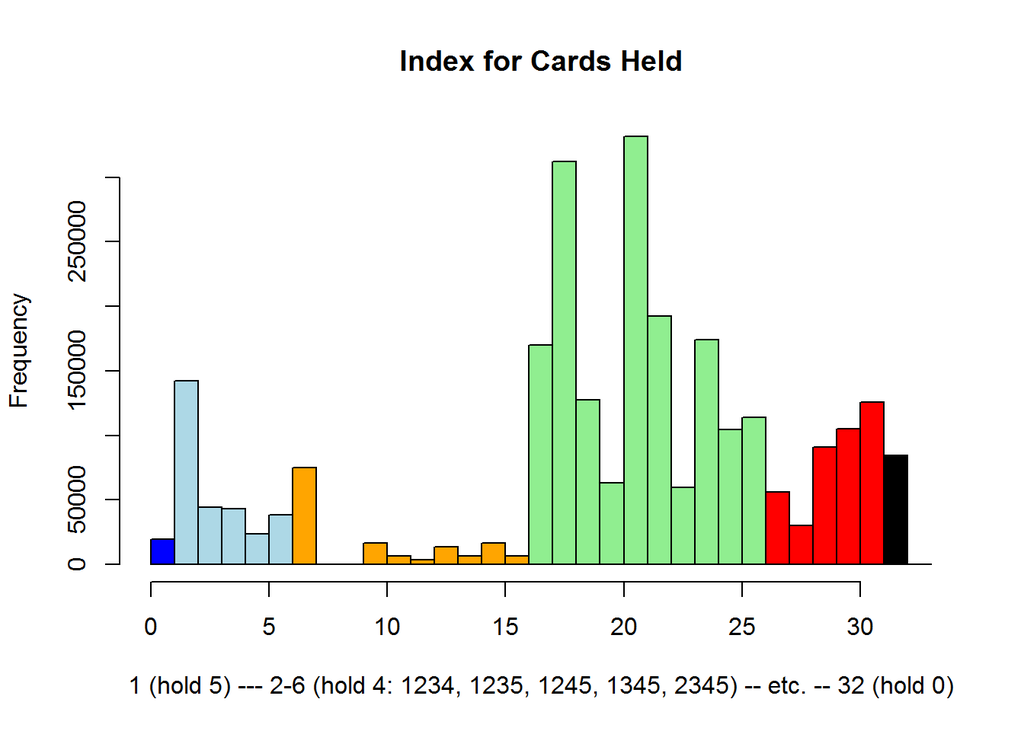

```
## [1] "Game JB 95:  Return: 0.9845 and Variance on Deal: 1.946"
##    Min. 1st Qu.  Median    Mean 3rd Qu.    Max.
## -70.800 -23.660  -9.799  -7.074   5.587 792.100
##    Min. 1st Qu.  Median    Mean 3rd Qu.    Max.
##  -73.28  -29.83  -20.05  -21.14  -10.71   13.54
##     Min.  1st Qu.   Median     Mean  3rd Qu.     Max.
## -106.500  -38.300  -17.860  -13.470    3.749  853.400
##      Min.   1st Qu.    Median      Mean   3rd Qu.      Max.
## -112.9000  -46.1600  -30.8800  -32.8300  -16.8500    0.5365
##     Min.  1st Qu.   Median     Mean  3rd Qu.     Max.
## -166.100  -62.780  -33.520  -30.410   -4.351  807.200
##    Min. 1st Qu.  Median    Mean 3rd Qu.    Max.
## -172.20  -74.77  -51.23  -53.82  -29.28    2.11
##    Min. 1st Qu.  Median    Mean 3rd Qu.    Max.
## -268.10 -109.80  -67.65  -58.96  -21.13  863.70
##     Min.  1st Qu.   Median     Mean  3rd Qu.     Max.
## -277.700 -122.400  -86.150  -89.890  -53.000    3.302
##    Min. 1st Qu.  Median    Mean 3rd Qu.    Max.
## -434.20 -190.10 -131.40 -123.10  -69.52  833.50
##      Min.   1st Qu.    Median      Mean   3rd Qu.      Max.
## -440.8000 -209.0000 -156.1000 -158.7000 -105.0000   -0.5941
##    Min. 1st Qu.  Median    Mean 3rd Qu.    Max.
##  -700.6  -345.9  -263.8  -250.8  -181.1   986.6
##      Min.   1st Qu.    Median      Mean   3rd Qu.      Max.
## -723.2000 -367.9000 -289.8000 -291.7000 -215.9000   -0.6603
##    Min. 1st Qu.  Median    Mean 3rd Qu.    Max.
##  -992.4  -525.4  -413.1  -391.4  -305.7  1357.0
##     Min.  1st Qu.   Median     Mean  3rd Qu.     Max.
## -995.700 -546.600 -439.000 -441.300 -336.300   -2.219
##    Min. 1st Qu.  Median    Mean 3rd Qu.    Max.
## -1334.0  -798.1  -643.4  -616.5  -495.6  1458.0
##     Min.  1st Qu.   Median     Mean  3rd Qu.     Max.
## -1334.00  -822.30  -672.60  -673.00  -538.20   -26.35
```

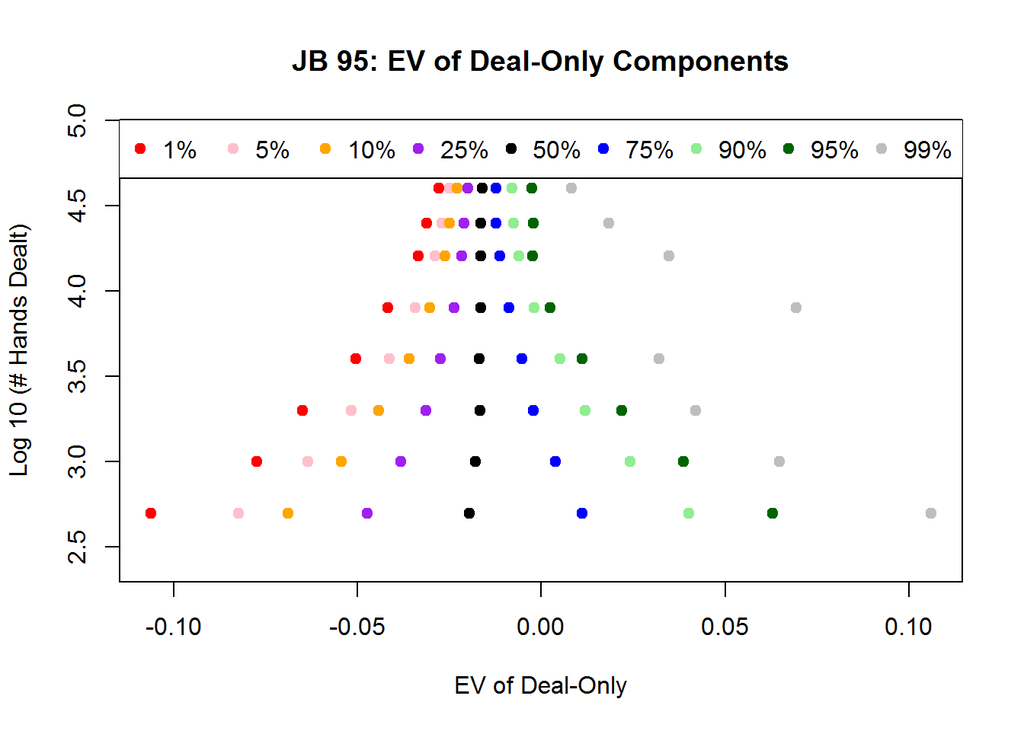

```
##    rndScore      ct      per
## 1        -1  899100      2.9
## 2         0 1158420      2.2
## 3         1  341496      7.6
## 4         2  124500     20.9
## 5         3   65148     39.9
## 6         4    4952    524.8
## 7         8    3744    694.2
## 8        17     752   3456.1
## 9        18      52  49980.0
## 10       19     132  19689.1
## 11       24     624   4165.0
## 12       49      36  72193.3
## 13      799       4 649740.0
## [1] 2598960      27
```

[output cut: 34 more lines]

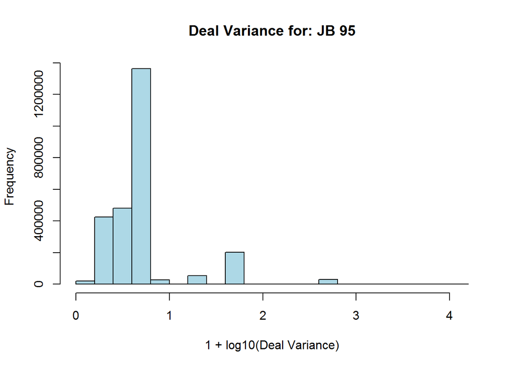

```
##
##
## This will assess the JB 95 means and variances
##
## 1 -1 2 14 15
## 2 799 3
## 3 49 4
## 4 8 5
## 5 4 6
## 6 3 7
## 7 2 8
## 8 1 9
## 9 0 10 11 12 13
## 10 24 16 17 18 19 20 21 22 23 24 25 26 27
## [1] 1269
##  num [1:1269, 1:10] 0 0 0 0 33 ...
##      rSum  ct
## 1       1   6
## 2      47  34
## 3    1081 104
## 4   16215  95
## 5  178365 155
## 6 1533939 875
##  chr [1:134459] "0-0-0-0-0-0-0-0-0-1" "0-0-0-0-0-0-0-0-0-1" ...
##  chr [1:1269] "0-0-0-0-0-0-0-0-0-1" "0-0-0-1-0-0-0-0-0-0" ...
##  int [1:134459] 1 1 1 1 1 1 1 1 1 1 ...
##  num [1:1269(1d)] 624 3744 54912 123552 96 ...
##  - attr(*, "dimnames")=List of 1
##   ..$ : chr [1:1269] "1" "2" "3" "4" ...
```

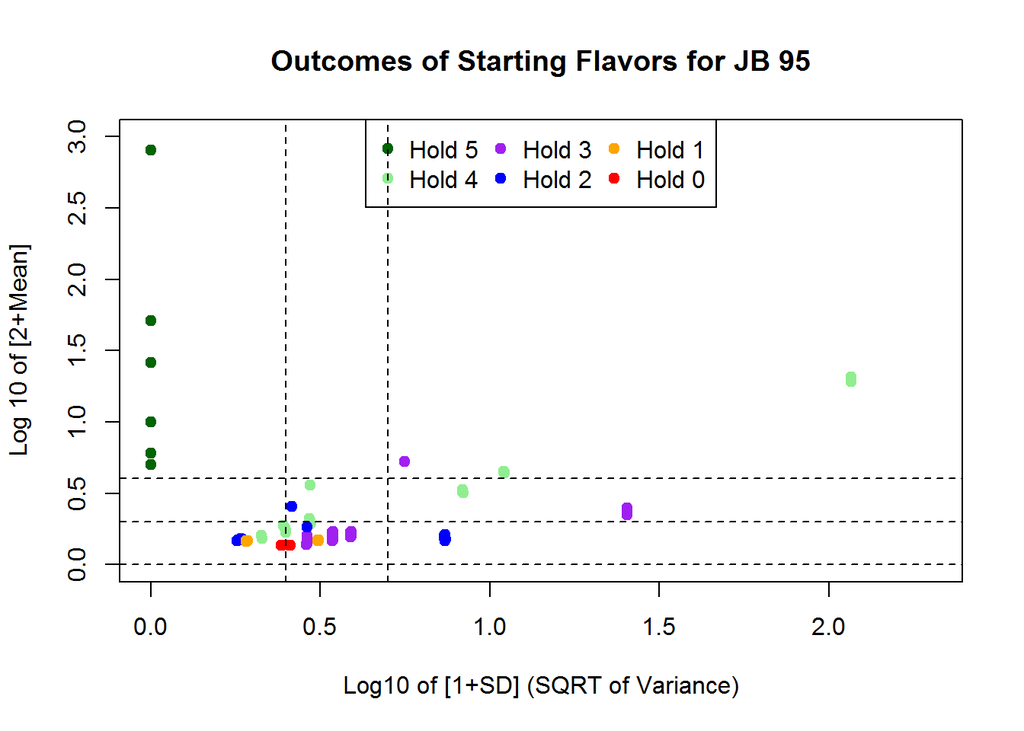

```
## [1] 0.9844981
## [1] 17.54967
##    scoreType    occPer   contRet    occFreq
## 2        799 40170.000  0.019891 0.00002490
## 3         49  9326.000  0.005254 0.00010723
## 10        24   423.200  0.056710 0.00236293
## 4          8    86.850  0.092112 0.01151397
## 5          4    91.810  0.043570 0.01089239
## 6          3    89.040  0.033692 0.01123055
## 7          2    13.430  0.148930 0.07446523
## 8          1     7.734  0.129303 0.12930324
## 9          0     4.648  0.000000 0.21513533
## 1         -1     1.835 -0.544964 0.54496425
##
## Printed table suggests JB 95 mean return: 0.984498 and overall variance: 19.49883
##
## List of 1
##  $ : int [1:10] 1 2 3 4 5 6 7 8 9 10
##
##    1
## 1269
##  int [1:10, 1] 1 2 3 4 5 6 7 8 9 10
##      [,1]
## [1,]    1
## [2,]    2
## [3,]    3
## [4,]    4
## [5,]    5
## [6,]    6
##
##
## Number of unique outcome types: 10
##
## Moving to assess the: 10 rows of outcomes
##
##
## Mean: 0.9844981      Variance: 19.49564
## List of 3
##  $ : int [1:1000] 1 1 1 1 1 1 1 1 1 1 ...
##  $ : int [1:1000] 1 1 1 1 1 1 1 1 1 1 ...
```

[output cut: 89 more lines]

```
## [1] 200
##  num [1:1269, 1:270] 0 0 0 0 0 0 0 0 0 0 ...
##  num [1:1269] 0 0 0 0 0 ...
## [1] 300
##  num [1:1269, 1:5] 0 0 0 0 0 0 0 0 0 0 ...
##  num [1:1269] 0 0 0 0 0 0 0 0 0 0 ...
## [1] 400
##
##
## Mean: 0.9844981      Variance: 370.0931
##
## Mean return per hand: 0.9844824 with total variance: 369.7508
## Mean return per hand: 98.446% with total variance (sd as % of total bet): 5,647,675 ( 1.49% )
##      1%      5%     10%     25%     50%     75%     90%     95%     99%
## -0.0427 -0.0366 -0.0324 -0.0251 -0.0173 -0.0071  0.0018  0.0101  0.0334
```

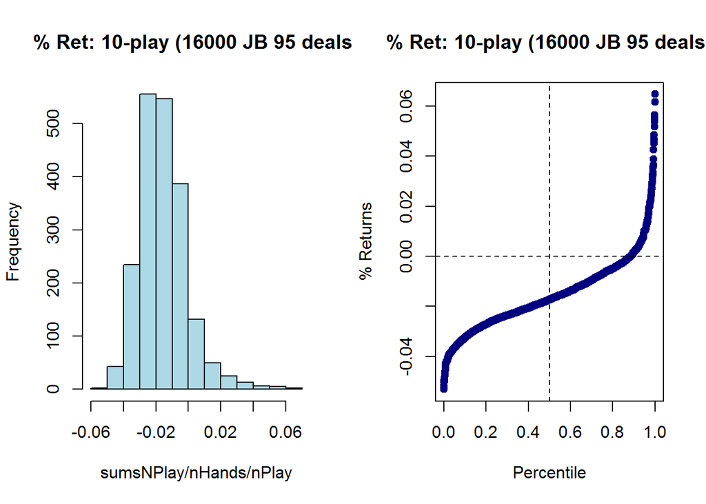

```
##
## Mean return per hand: 0.9844943 with total variance: 136.378
## Mean return per hand: 98.4% with total variance (sd as % of total bet): 2,128,016 ( 1.82% )
##      1%      5%     10%     25%     50%     75%     90%     95%     99%
## -0.0509 -0.0433 -0.0377 -0.0280 -0.0175 -0.0058  0.0073  0.0158  0.0370
```

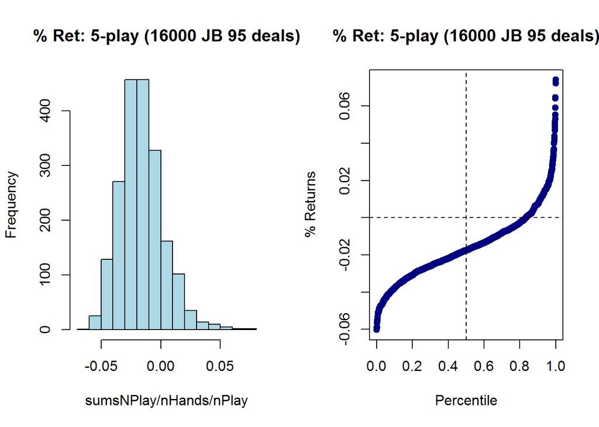

```
##  num [1:1269, 1:10] 0 0 0 0 0.702 ...
##  - attr(*, "dimnames")=List of 2
##   ..$ : NULL
##   ..$ : chr [1:10] "" "" "" "" ...
## [1] TRUE
## [1] TRUE
```

```r
proc.time() - startTime
```

```
##    user  system elapsed
##  119.31   13.70  133.91
```

```r
# Extract JB 95 holds from JB 95 game data, and compare with JB 96
jb95Holds <- jb95GameData$gameHolds
jb96_vs_jb95Holds <- diffHolds(jb96Holds, jb95Holds)
sum(jb96_vs_jb95Holds)
```

```
## [1] 627
```

```r
if (sum(jb96_vs_jb95Holds) > 0) {
    cbind(cardSmall[jb96_vs_jb95Holds, ],
          jb96Holds[jb96_vs_jb95Holds, ],
          jb95Holds[jb96_vs_jb95Holds, ]
          )[sort(sample(1:sum(jb96_vs_jb95Holds), 20)), ]
}
```

```
##       [,1] [,2] [,3] [,4] [,5] [,6] [,7] [,8] [,9] [,10] [,11] [,12] [,13]
##  [1,]    1    5   10   12   23    1    5   10   12    NA     1    NA    10
##  [2,]    1    7   10   12   23    1    7   10   12    NA     1    NA    10
##  [3,]    1    4    9   23   25   NA   NA   NA   23    25     1    NA    NA
##  [4,]    1    4   13   24   25   NA   NA   NA   24    25     1    NA    13
##  [5,]    1    6   10   13   25    1    6   10   13    NA     1    NA    10
##  [6,]    1    8   10   11   26    1    8   10   11    NA     1    NA    10
##  [7,]    2   10   13   16   20   NA   10   13   NA    NA    NA    NA    13
##  [8,]    2   10   13   17   31   NA   10   13   NA    NA    NA    NA    13
##  [9,]    2   10   13   20   21   NA   10   13   NA    NA    NA    NA    13
## [10,]    7   10   13   15   34   NA   10   13   NA    NA    NA    NA    13
## [11,]   10   11   15   34   52   10   11   NA   NA    NA    NA    11    NA
## [12,]    3   10   13   17   34   NA   10   13   NA    NA    NA    NA    13
## [13,]    3    5    6   23   24    3    5    6   NA    NA    NA    NA    NA
## [14,]    3    8   23   24   39   NA   NA   23   24    NA    NA    NA    NA
```

[output cut: 27 more lines]

The data are run for the BP 75 game, with holds extracted and compared to BP 85:

```r
# Define the paytable and simulate the holds (BP 75)
startTime <- proc.time()
bp75hnd2Score <- data.frame(idx=gameIndex, val=c( -1,
                                                 799, 49,  6,  4,  3,
                                                   2,  1,  0,  0,  0,
                                                   0, -1, -1, 79, 79,
                                                  79, 39, 39, 39, 39,
                                                  24, 24, 24, 24, 24
                                            )
                        )
bp75GameData <- genGame(hnd2Score=bp75hnd2Score, useGameName="BP 75")
```

```
##     Min.  1st Qu.   Median     Mean  3rd Qu.     Max.
##  -1.0000  -1.0000  -1.0000  -0.6661  -1.0000 799.0000
##
## # A tibble: 12 × 2
##    aScores      ct
##      <dbl>   <int>
## 1       -1 2062860
## 2        0  337920
## 3        1  123552
## 4        2   54912
## 5        3   10200
## 6        4    5108
## 7        6    3744
## 8       24     432
## 9       39     144
## 10      49      36
## 11      79      48
## 12     799       4
##
##    Min. 1st Qu.  Median    Mean 3rd Qu.    Max.
## -1.0000 -0.9375 -0.8750 -0.6661 -0.6250 79.0000
##
##    Min. 1st Qu.  Median    Mean 3rd Qu.    Max.
## -0.9107 -0.8138 -0.8138 -0.6661 -0.6624  5.3880
##
##    Min. 1st Qu.  Median    Mean 3rd Qu.    Max.
## -0.8141 -0.7741 -0.6916 -0.6661 -0.6524  0.6294
##
##    Min. 1st Qu.  Median    Mean 3rd Qu.    Max.
## -0.7193 -0.7093 -0.7093 -0.6661 -0.5712 -0.5609
##
##
## [1] 0
## [1] 0
## [1] 0
## [1] 0
##     Min.  1st Qu.   Median     Mean  3rd Qu.     Max.
##  -0.6447  -0.5199  -0.1967  -0.0198  -0.0426 799.0000
##
## [1] 0.9801469
```

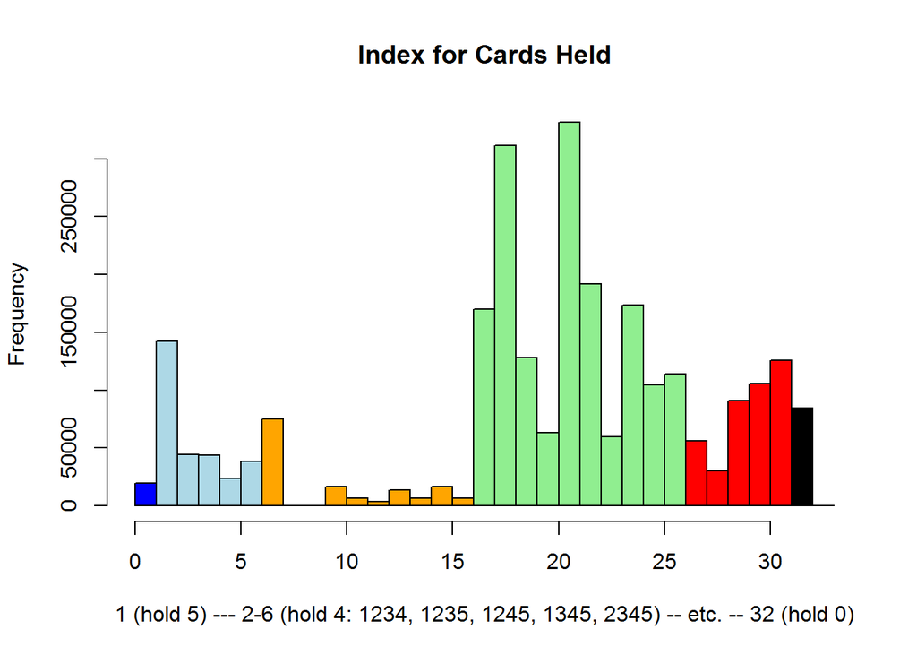

```
## [1] "Game BP 75:  Return: 0.98015 and Variance on Deal: 2.08"
##    Min. 1st Qu.  Median    Mean 3rd Qu.    Max.
## -70.000 -26.620 -13.060  -9.365   3.065 790.600
##    Min. 1st Qu.  Median    Mean 3rd Qu.    Max.
##  -72.60  -32.01  -22.07  -22.93  -12.22   11.62
##      Min.   1st Qu.    Median      Mean   3rd Qu.      Max.
## -112.5000  -42.9500  -23.5000  -17.4900    0.3269  845.9000
##      Min.   1st Qu.    Median      Mean   3rd Qu.      Max.
## -119.4000  -51.5400  -34.9700  -36.4700  -19.5400    0.5162
##    Min. 1st Qu.  Median    Mean 3rd Qu.    Max.
## -176.40  -74.06  -44.92  -39.60  -12.68  795.80
##     Min.  1st Qu.   Median     Mean  3rd Qu.     Max.
## -177.200  -83.600  -60.250  -61.680  -35.680    1.259
##    Min. 1st Qu.  Median    Mean 3rd Qu.    Max.
## -296.00 -130.10  -86.67  -76.16  -36.33  837.40
##    Min. 1st Qu.  Median    Mean 3rd Qu.    Max.
## -296.00 -141.60 -103.90 -105.70  -68.06    3.18
##    Min. 1st Qu.  Median    Mean 3rd Qu.    Max.
##  -471.9  -229.6  -168.8  -158.8  -102.0   788.2
##     Min.  1st Qu.   Median     Mean  3rd Qu.     Max.
## -472.500 -247.000 -190.800 -192.400 -134.400   -2.658
##    Min. 1st Qu.  Median    Mean 3rd Qu.    Max.
##  -750.8  -424.0  -341.0  -321.9  -245.6   945.5
##     Min.  1st Qu.   Median     Mean  3rd Qu.     Max.
## -762.700 -442.400 -361.700 -359.100 -277.800   -4.474
##    Min. 1st Qu.  Median    Mean 3rd Qu.    Max.
## -1109.0  -642.8  -525.9  -501.3  -405.4  1237.0
##      Min.   1st Qu.    Median      Mean   3rd Qu.      Max.
## -1148.000  -663.000  -549.000  -546.500  -438.000    -4.912
##    Min. 1st Qu.  Median    Mean 3rd Qu.    Max.
## -1565.0  -984.6  -814.7  -790.8  -654.1  1351.0
##    Min. 1st Qu.  Median    Mean 3rd Qu.    Max.
## -1565.0 -1005.0  -849.3  -839.5  -692.6   -47.5
```

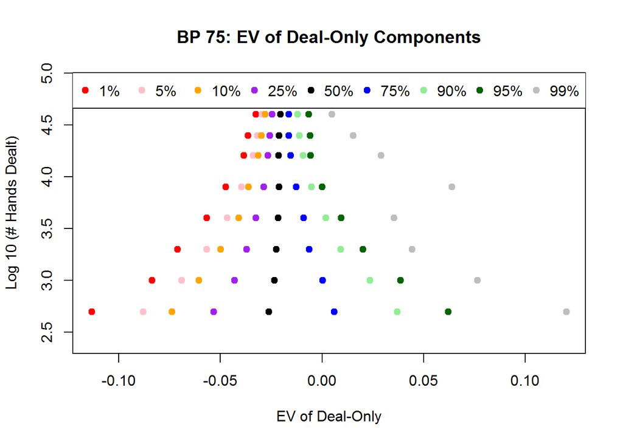

```
##    rndScore      ct      per
## 1        -1  911328      2.9
## 2         0 1146192      2.3
## 3         1  465048      5.6
## 4         2     948   2741.5
## 5         3   48252     53.9
## 6         4   17624    147.5
## 7         6    7968    326.2
## 8        17     752   3456.1
## 9        18      52  49980.0
## 10       19     132  19689.1
## 11       24     432   6016.1
## 12       39     144  18048.3
## 13       49      36  72193.3
## 14       79      48  54145.0
```

[output cut: 36 more lines]

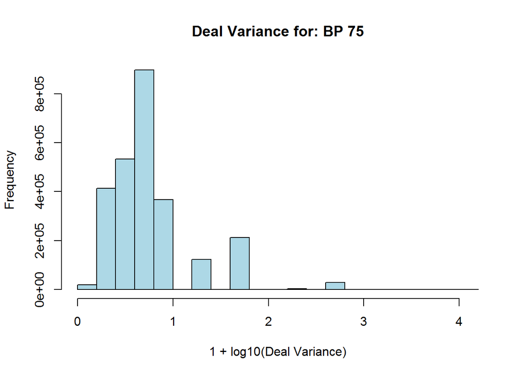

```
##
##
## This will assess the BP 75 means and variances
##
## 1 -1 2 14 15
## 2 799 3
## 3 49 4
## 4 6 5
## 5 4 6
## 6 3 7
## 7 2 8
## 8 1 9
## 9 0 10 11 12 13
## 10 79 16 17 18
## 11 39 19 20 21 22
## 12 24 23 24 25 26 27
## [1] 1647
##  num [1:1647, 1:12] 0 0 0 0 0 0 0 0 33 0 ...
##      rSum  ct
## 1       1   8
## 2      47  34
## 3    1081 106
## 4   16215  95
## 5  178365 451
## 6 1533939 953
##  chr [1:134459] "0-0-0-0-0-0-0-0-0-1-0-0" ...
##  chr [1:1647] "0-0-0-0-0-0-0-0-0-1-0-0" "0-0-0-0-0-0-0-0-0-0-1-0" ...
##  int [1:134459] 1 1 1 1 1 1 1 1 1 1 ...
##  num [1:1647(1d)] 48 144 432 3744 4224 ...
##  - attr(*, "dimnames")=List of 1
##   ..$ : chr [1:1647] "1" "2" "3" "4" ...
```

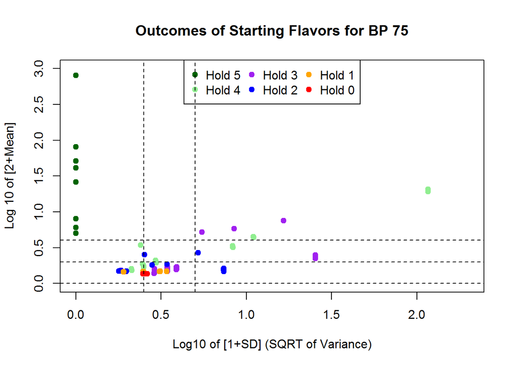

```
## [1] 0.9801469
## [1] 18.6737
##    scoreType    occPer   contRet    occFreq
## 2        799 40230.000  0.019859 0.00002485
## 10        79  5106.000  0.015471 0.00019584
## 3         49  9346.000  0.005243 0.00010699
## 11        39  1897.000  0.020563 0.00052725
## 12        24   610.100  0.039339 0.00163914
## 4          6    86.870  0.069069 0.01151142
## 5          4    91.880  0.043535 0.01088366
## 6          3    88.740  0.033805 0.01126847
## 7          2    13.430  0.148873 0.07443631
## 8          1     7.736  0.129263 0.12926285
## 9          0     4.645  0.000000 0.21527153
## 1         -1     1.835 -0.544872 0.54487169
##
## Printed table suggests BP 75 mean return: 0.980148 and overall variance: 20.75093
##
## List of 1
##  $ : int [1:12] 1 2 3 4 5 6 7 8 9 10 ...
##
##    1
## 1647
##  int [1:12, 1] 1 2 3 4 5 6 7 8 9 10 ...
##      [,1]
## [1,]    1
## [2,]    2
## [3,]    3
## [4,]    4
## [5,]    5
## [6,]    6
##
##
## Number of unique outcome types: 12
##
## Moving to assess the: 12 rows of outcomes
##
##
## Mean: 0.9801469      Variance: 20.75378
## List of 3
```

[output cut: 109 more lines]

```
## [1] 500
##  num [1:1647, 1:150] 0 0 0 0 0 0 0 0 0 0 ...
##  num [1:1647] 0 0 0 0 0 0 0 0 0 0 ...
## [1] 600
##  num [1:1647, 1:10] 0 0 0 0 0 0 0 0 0 0 ...
##  num [1:1647] 0 0 0 0 0 0 0 0 0 0 ...
## [1] 700
##
##
## Mean: 0.9801469      Variance: 394.7444
##
## Mean return per hand: 0.9801308 with total variance: 394.3983
## Mean return per hand: 98.009% with total variance (sd as % of total bet): 6,005,956 ( 1.53% )
##      1%      5%     10%     25%     50%     75%     90%     95%     99%
## -0.0487 -0.0418 -0.0377 -0.0299 -0.0215 -0.0114 -0.0022  0.0061  0.0303
```

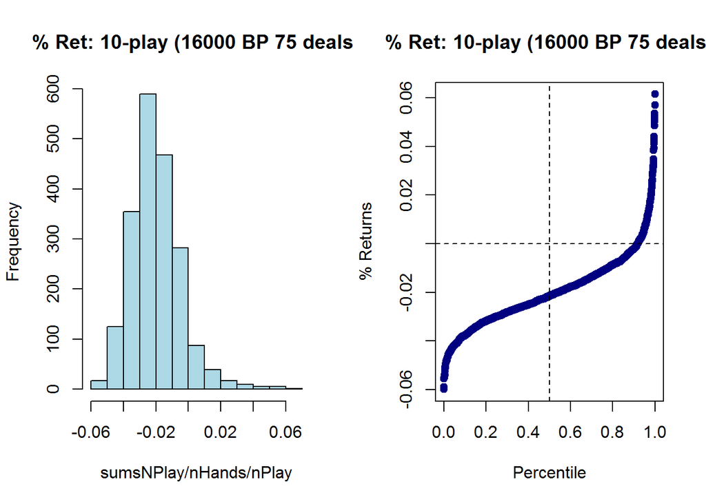

```
##
## Mean return per hand: 0.9801439 with total variance: 145.3524
## Mean return per hand: 97.962% with total variance (sd as % of total bet): 2,289,651 ( 1.89% )
##      1%      5%     10%     25%     50%     75%     90%     95%     99%
## -0.0568 -0.0491 -0.0439 -0.0326 -0.0218 -0.0095  0.0037  0.0124  0.0360
```

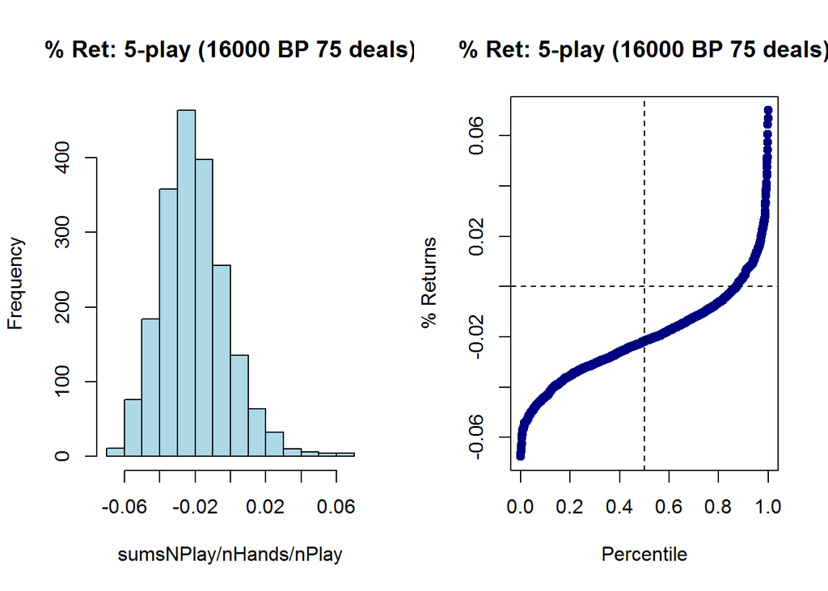

```
##  num [1:1647, 1:12] 0 0 0 0 0 ...
##  - attr(*, "dimnames")=List of 2
##   ..$ : NULL
##   ..$ : chr [1:12] "" "" "" "" ...
## [1] TRUE
## [1] TRUE
```

```r
proc.time() - startTime
```

```
##    user  system elapsed
##  156.00   17.15  173.97
```

```r
# Extract BP 75 holds from JB 95 game data, and compare with JB 96
bp75Holds <- bp75GameData$gameHolds
bp85_vs_bp75Holds <- diffHolds(bp85Holds, bp75Holds)
sum(bp85_vs_bp75Holds)
```

```
## [1] 47
```

```r
if (sum(bp85_vs_bp75Holds) > 0) {
    cbind(cardSmall[bp85_vs_bp75Holds, ],
          bp85Holds[bp85_vs_bp75Holds, ],
          bp75Holds[bp85_vs_bp75Holds, ]
          )[sort(sample(1:sum(bp85_vs_bp75Holds), 20)), ]
}
```

```
##       [,1] [,2] [,3] [,4] [,5] [,6] [,7] [,8] [,9] [,10] [,11] [,12] [,13]
##  [1,]    9   10   11   22   25    9   NA   NA   22    NA     9    10    11
##  [2,]    9   10   12   22   24    9   NA   NA   22    NA     9    10    12
##  [3,]    9   10   12   22   37    9   NA   NA   22    NA     9    10    12
##  [4,]    9   11   22   36   38    9   NA   22   NA    NA     9    11    NA
##  [5,]    9   22   37   49   51    9   22   NA   NA    NA     9    NA    37
##  [6,]    9   10   22   37   51    9   NA   22   NA    NA     9    10    NA
##  [7,]    9   11   22   36   51    9   NA   22   NA    NA     9    11    NA
##  [8,]    9   10   11   23   25   NA   10   NA   23    NA     9    10    11
##  [9,]   10   11   23   35   38   10   NA   23   NA    NA    10    11    NA
## [10,]   10   23   35   50   51   10   23   NA   NA    NA    10    NA    35
## [11,]    9   10   23   24   38   NA   10   23   NA    NA     9    10    NA
## [12,]    9   10   23   25   37   NA   10   23   NA    NA     9    10    NA
## [13,]    9   10   23   37   51   NA   10   23   NA    NA     9    10    NA
## [14,]   10   11   23   35   51   10   NA   23   NA    NA    10    11    NA
```

[output cut: 27 more lines]

Next, 1/3/5/10 play JB 95 data are simulated for 2,000 trials of 1k, 2k, 4k, 8k, 16k, 24k, 32k, 40k deals:

```r
nDealSim <- c(1000, 2000, 4000, 8000, 16000, 24000, 32000, 40000)
nSims <- 2000
useList <- jb95GameData
gameName <- "JB 95"
simOut <- matrix(data=0, nrow=4*length(nDealSim), ncol=nSims+2)  # nSims trials, plus nPlay and nHand

curRow <- 1
for (nUse in nDealSim) {
    simOut[curRow:(curRow+3), 1] <- c(1, 3, 5, 10)
    simOut[curRow:(curRow+3), 2] <- rep(nUse, 4)

    simOut[curRow, -(1:2)] <- sim_NPlay(keyFrame=useList$game_01Play$dfOutcome,
                                        useName=gameName, nPlay=1, nHands=nUse, nSim=nSims
                                        )
    simOut[curRow+1, -(1:2)] <- sim_NPlay(keyFrame=useList$game_03Play$dfOutcome,
                                          useName=gameName, nPlay=3, nHands=nUse, nSim=nSims
                                          )
    simOut[curRow+2, -(1:2)] <- sim_NPlay(keyFrame=useList$game_05Play$dfOutcome,
                                          useName=gameName, nPlay=5, nHands=nUse, nSim=nSims
                                          )
    simOut[curRow+3, -(1:2)] <- sim_NPlay(keyFrame=useList$game_10Play$out10Play,
                                          useName=gameName, nPlay=10, nHands=nUse, nSim=nSims
                                          )

    curRow <- curRow + 4

}
```

```
##
## Mean return per hand: 0.9844978 with total variance: 19.49537
## Mean return per hand: 98.697% with total variance (sd as % of total bet): 21,228 ( 14.57% )
##      1%      5%     10%     25%     50%     75%     90%     95%     99%
## -0.1670 -0.1310 -0.1110 -0.0750 -0.0350  0.0070  0.0540  0.0960  0.7961
```

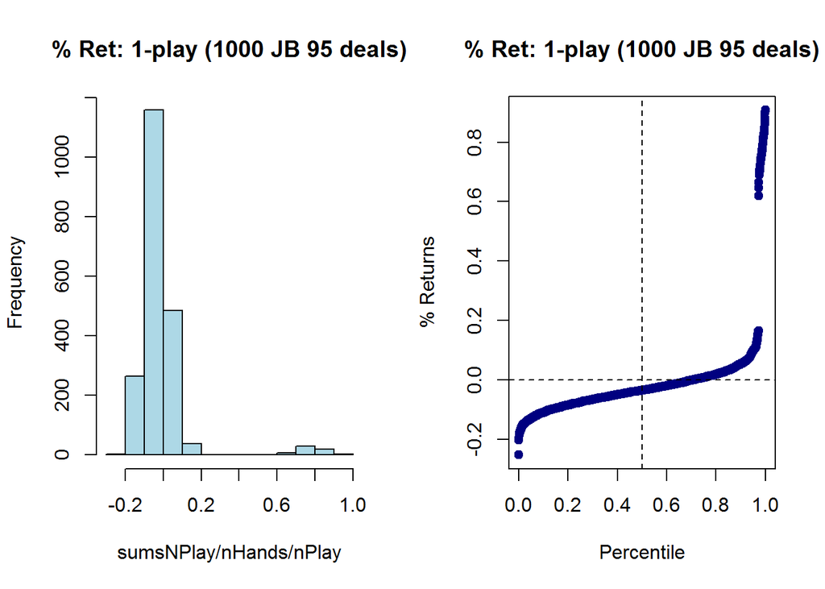

```
##
## Mean return per hand: 0.9844976 with total variance: 70.16407
## Mean return per hand: 98.515% with total variance (sd as % of total bet): 74,833 ( 9.12% )
##      1%      5%     10%     25%     50%     75%     90%     95%     99%
## -0.1383 -0.1037 -0.0874 -0.0610 -0.0320 -0.0003  0.0410  0.2140  0.2910
```

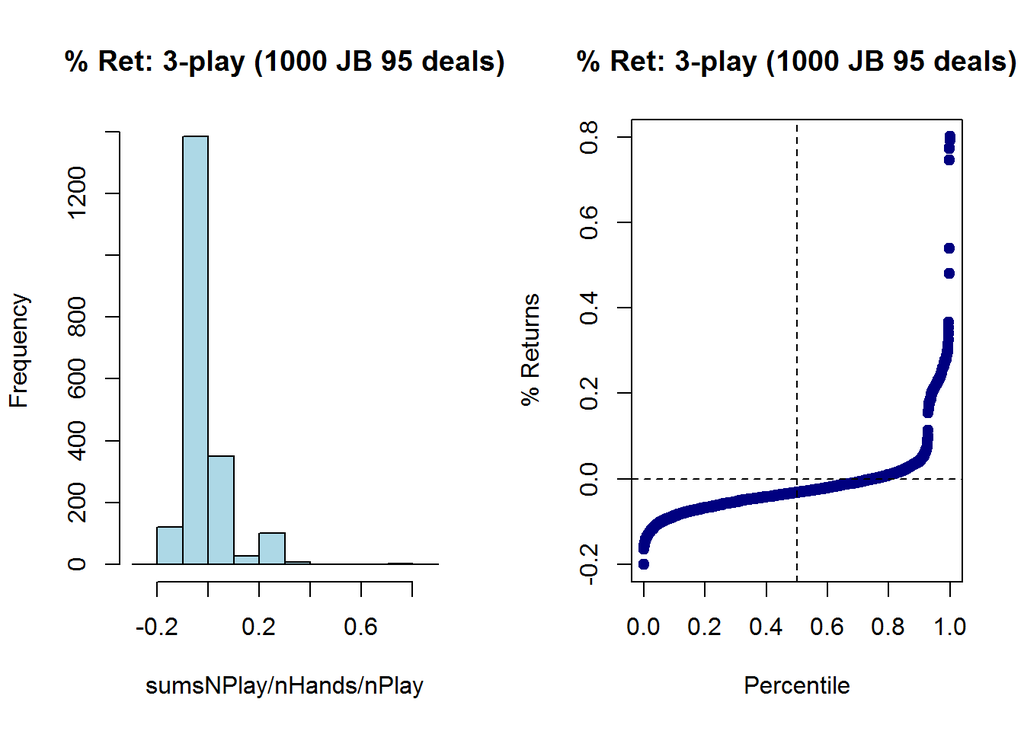

```
##
## Mean return per hand: 0.9844943 with total variance: 136.378
## Mean return per hand: 98.775% with total variance (sd as % of total bet): 177,725 ( 8.43% )
##      1%      5%     10%     25%     50%     75%     90%     95%     99%
## -0.1162 -0.0932 -0.0796 -0.0568 -0.0292  0.0052  0.0902  0.1378  0.2334
```

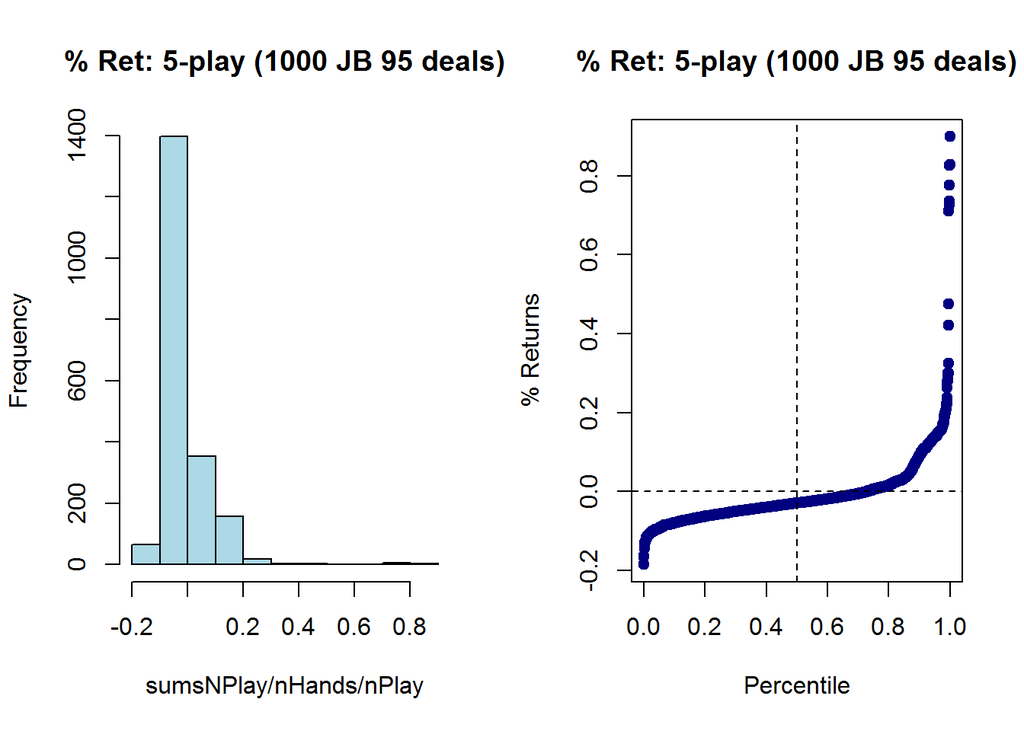

```
##
## Mean return per hand: 0.9844824 with total variance: 369.7508
## Mean return per hand: 98.415% with total variance (sd as % of total bet): 348,600 ( 5.9% )
##      1%      5%     10%     25%     50%     75%     90%     95%     99%
## -0.1097 -0.0860 -0.0745 -0.0529 -0.0248  0.0107  0.0536  0.0784  0.1362
```

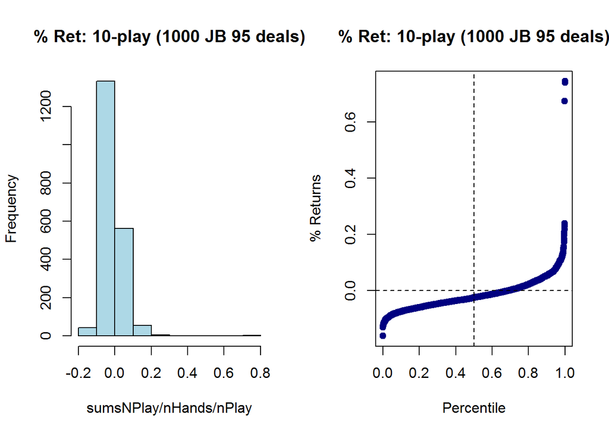

```
##
## Mean return per hand: 0.9844978 with total variance: 19.49537
## Mean return per hand: 98.278% with total variance (sd as % of total bet): 38,791 ( 9.85% )
##      1%      5%     10%     25%     50%     75%     90%     95%     99%
## -0.1250 -0.1015 -0.0870 -0.0645 -0.0350 -0.0035  0.0325  0.0840  0.4010
```

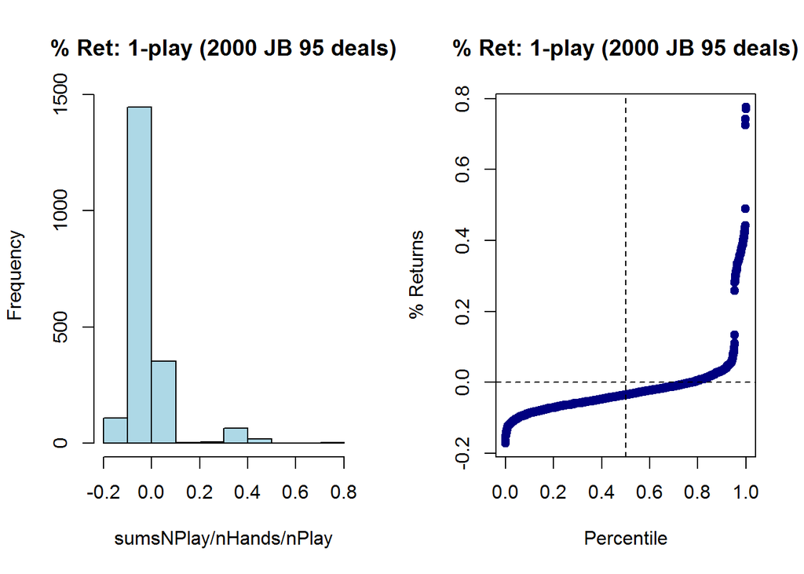

```
##
## Mean return per hand: 0.9844976 with total variance: 70.16407
## Mean return per hand: 98.402% with total variance (sd as % of total bet): 145,392 ( 6.36% )
##      1%      5%     10%     25%     50%     75%     90%     95%     99%
## -0.1005 -0.0818 -0.0697 -0.0522 -0.0305 -0.0030  0.0735  0.1110  0.2324
```

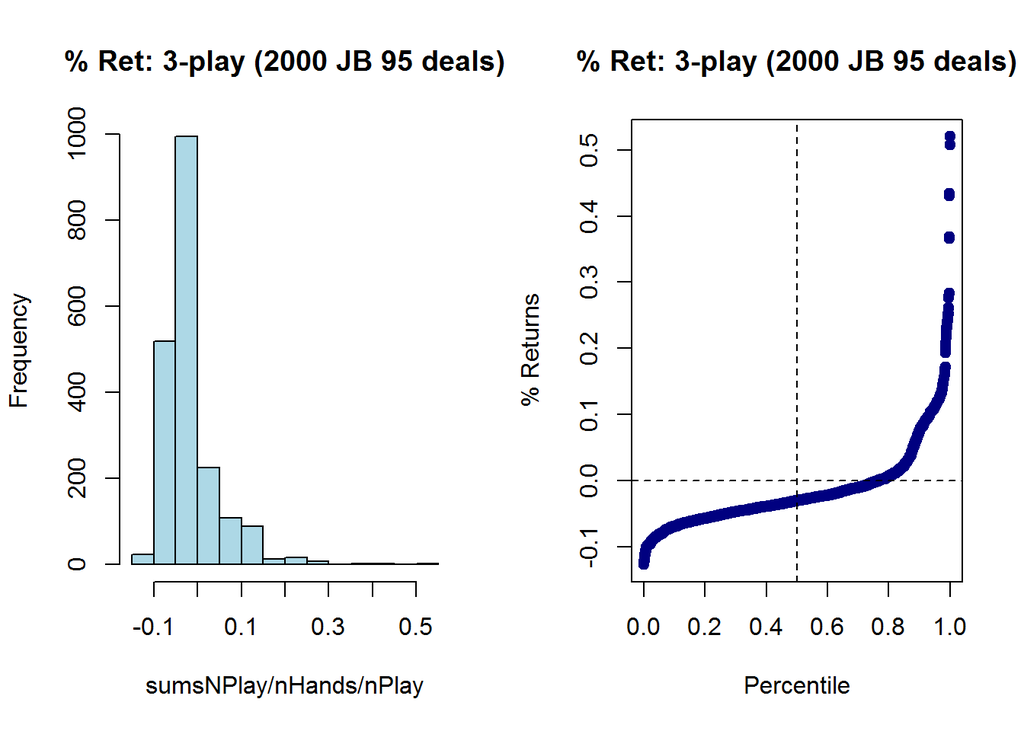

```
##
## Mean return per hand: 0.9844943 with total variance: 136.378
## Mean return per hand: 98.514% with total variance (sd as % of total bet): 277,751 ( 5.27% )
##      1%      5%     10%     25%     50%     75%     90%     95%     99%
## -0.0946 -0.0758 -0.0649 -0.0489 -0.0253  0.0060  0.0529  0.0733  0.1367
```

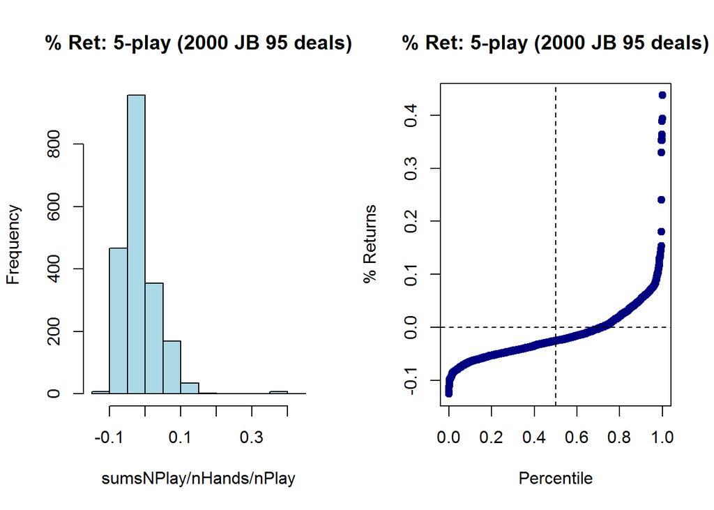

```
##
## Mean return per hand: 0.9844824 with total variance: 369.7508
## Mean return per hand: 98.586% with total variance (sd as % of total bet): 938,154 ( 4.84% )
##      1%      5%     10%     25%     50%     75%     90%     95%     99%
## -0.0825 -0.0666 -0.0584 -0.0425 -0.0210  0.0061  0.0333  0.0518  0.1028
```

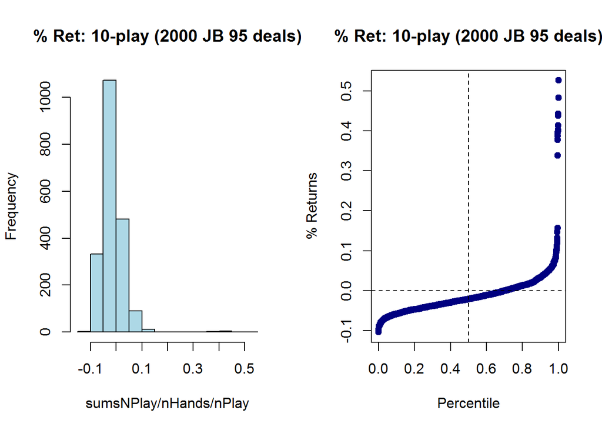

```
##
## Mean return per hand: 0.9844978 with total variance: 19.49537
## Mean return per hand: 98.461% with total variance (sd as % of total bet): 75,541 ( 6.87% )
##      1%      5%     10%     25%     50%     75%     90%     95%     99%
## -0.0993 -0.0805 -0.0710 -0.0520 -0.0322 -0.0070  0.0441  0.1575  0.2050
```

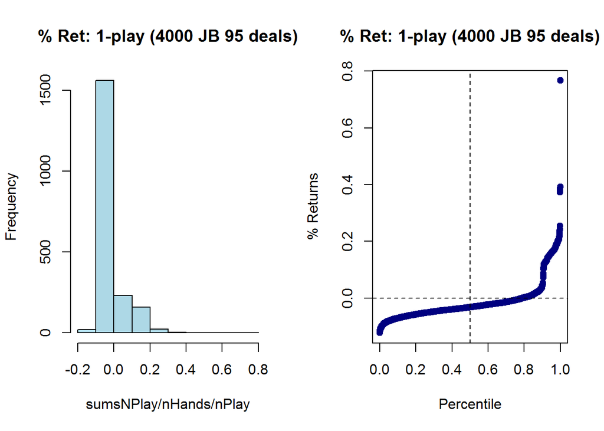

```
##
## Mean return per hand: 0.9844976 with total variance: 70.16407
## Mean return per hand: 98.352% with total variance (sd as % of total bet): 267,729 ( 4.31% )
##      1%      5%     10%     25%     50%     75%     90%     95%     99%
## -0.0840 -0.0673 -0.0593 -0.0450 -0.0270  0.0023  0.0419  0.0581  0.1274
```

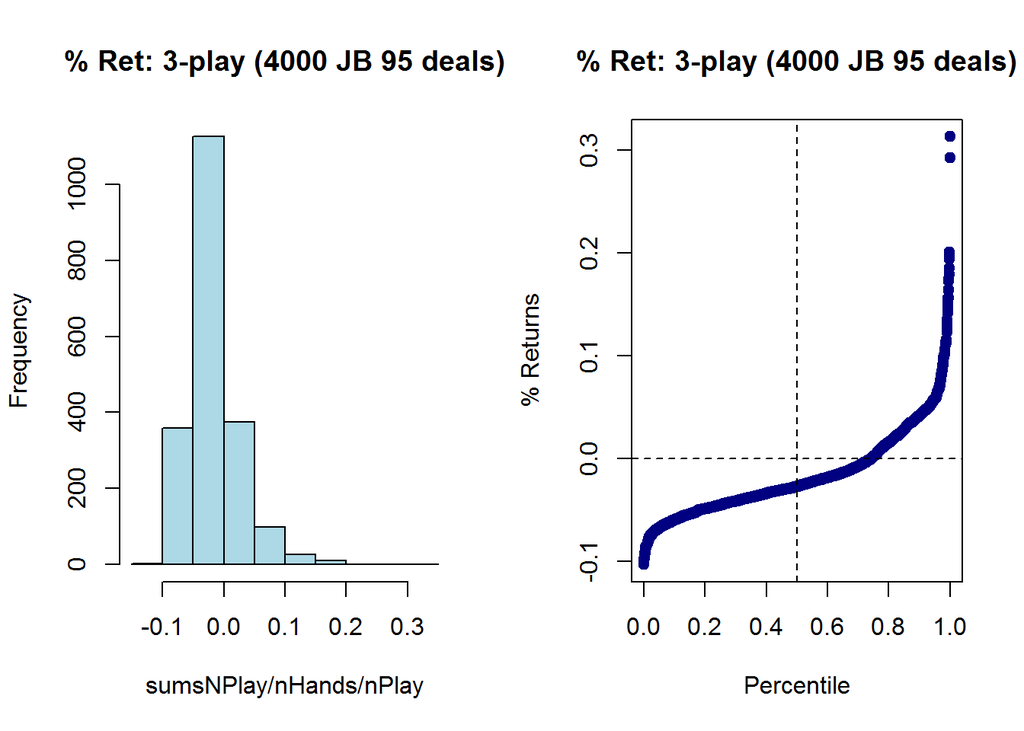

```
##
## Mean return per hand: 0.9844943 with total variance: 136.378
## Mean return per hand: 98.449% with total variance (sd as % of total bet): 539,034 ( 3.67% )
##      1%      5%     10%     25%     50%     75%     90%     95%     99%
## -0.0728 -0.0607 -0.0525 -0.0405 -0.0224  0.0015  0.0278  0.0494  0.1244
```

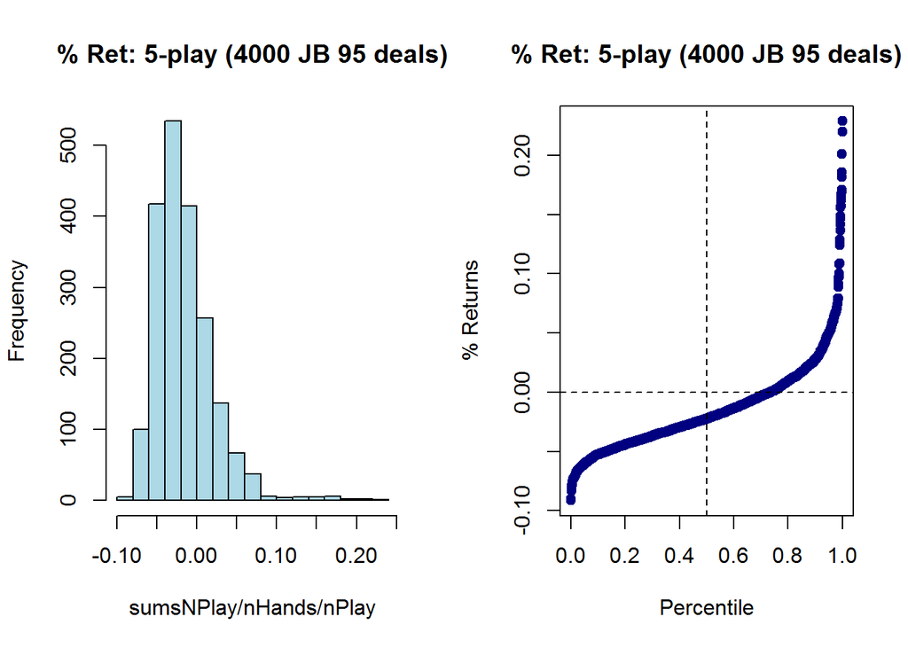

```
##
## Mean return per hand: 0.9844824 with total variance: 369.7508
## Mean return per hand: 98.338% with total variance (sd as % of total bet): 1,341,713 ( 2.9% )
##      1%      5%     10%     25%     50%     75%     90%     95%     99%
## -0.0679 -0.0554 -0.0497 -0.0345 -0.0192 -0.0020  0.0178  0.0300  0.0520
```

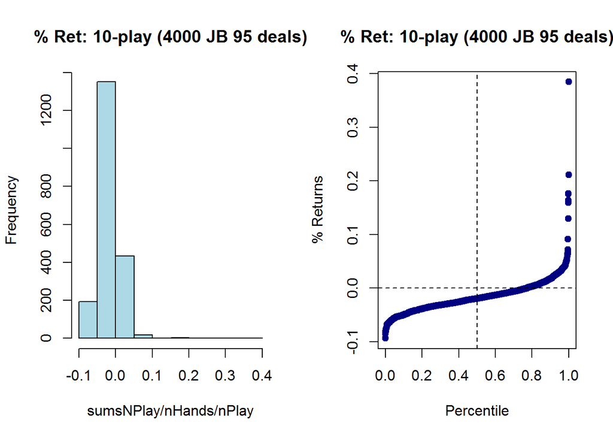

```
##
## Mean return per hand: 0.9844978 with total variance: 19.49537
## Mean return per hand: 98.297% with total variance (sd as % of total bet): 146,978 ( 4.79% )
##      1%      5%     10%     25%     50%     75%     90%     95%     99%
## -0.0808 -0.0675 -0.0603 -0.0461 -0.0298 -0.0092  0.0594  0.0783  0.1518
```

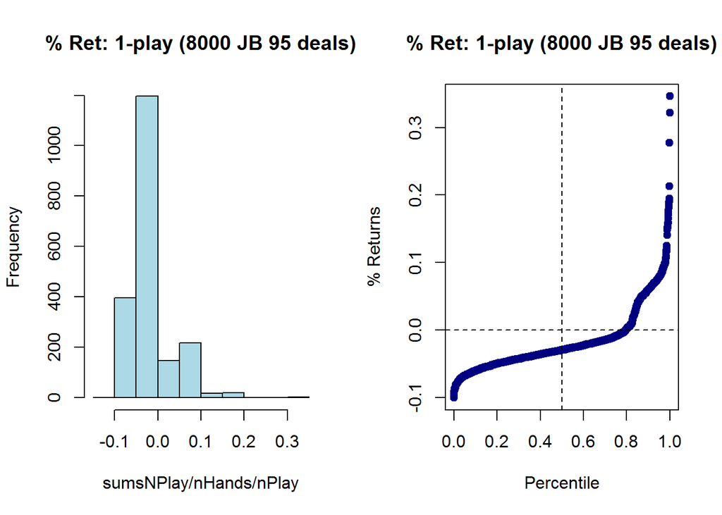

```
##
## Mean return per hand: 0.9844976 with total variance: 70.16407
## Mean return per hand: 98.5% with total variance (sd as % of total bet): 592,121 ( 3.21% )
##      1%      5%     10%     25%     50%     75%     90%     95%     99%
## -0.0644 -0.0556 -0.0491 -0.0377 -0.0209  0.0015  0.0263  0.0460  0.0922
```

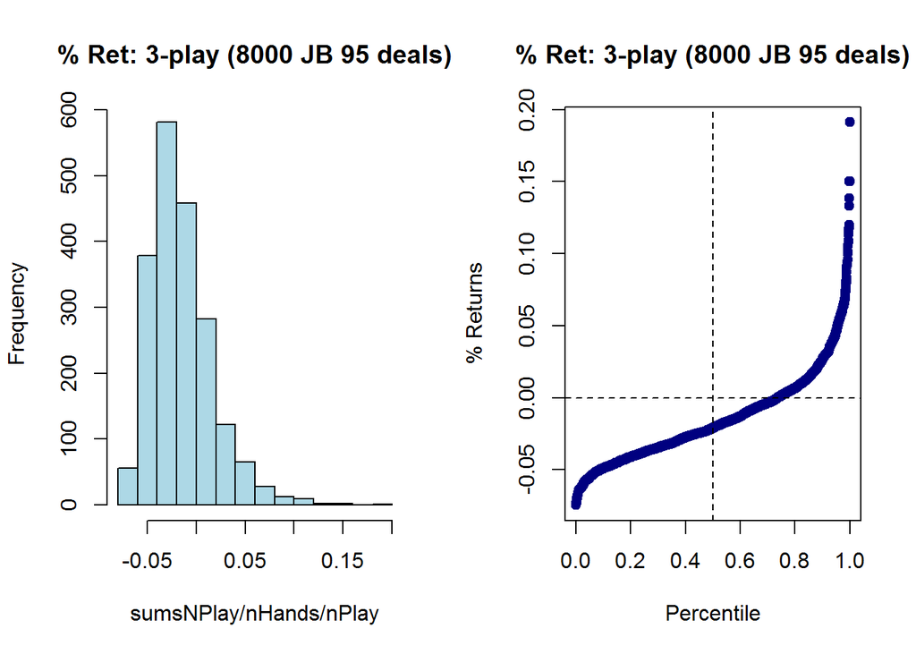

```
##
## Mean return per hand: 0.9844943 with total variance: 136.378
## Mean return per hand: 98.385% with total variance (sd as % of total bet): 1,078,183 ( 2.6% )
##      1%      5%     10%     25%     50%     75%     90%     95%     99%
## -0.0596 -0.0510 -0.0454 -0.0336 -0.0197 -0.0028  0.0161  0.0296  0.0707
```

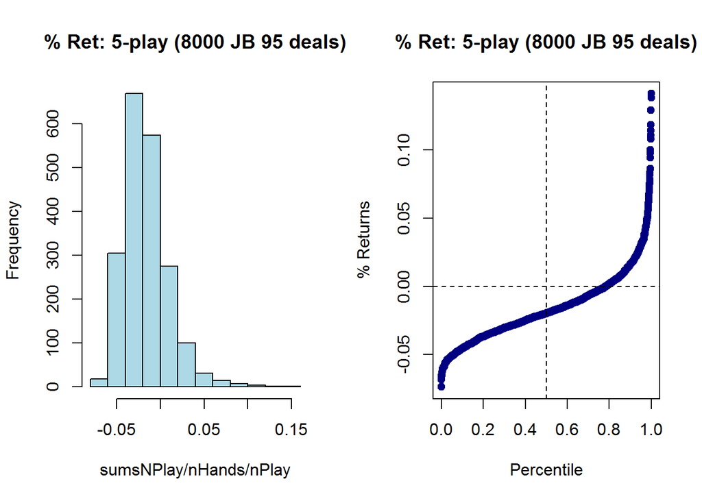

```
##
## Mean return per hand: 0.9844824 with total variance: 369.7508
## Mean return per hand: 98.349% with total variance (sd as % of total bet): 3,070,113 ( 2.19% )
##      1%      5%     10%     25%     50%     75%     90%     95%     99%
## -0.0553 -0.0470 -0.0412 -0.0302 -0.0184 -0.0055  0.0083  0.0162  0.0691
```

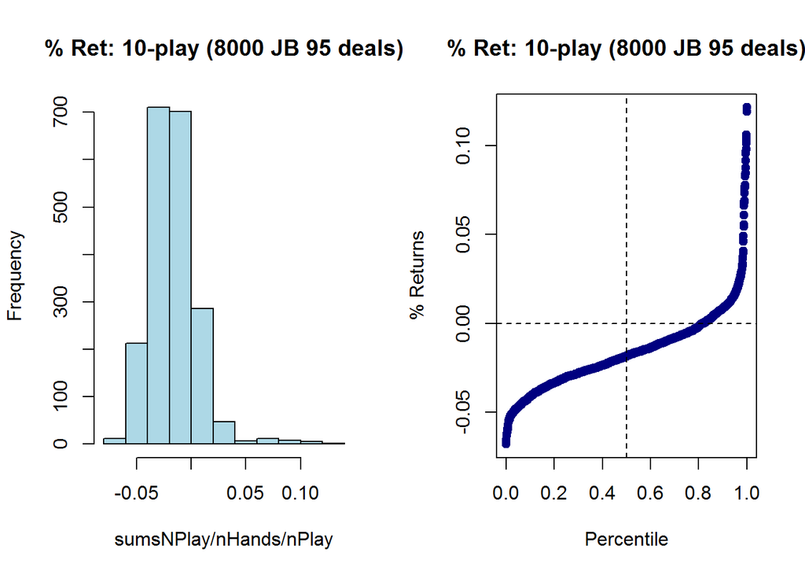

```
##
## Mean return per hand: 0.9844978 with total variance: 19.49537
## Mean return per hand: 98.315% with total variance (sd as % of total bet): 303,378 ( 3.44% )
##      1%      5%     10%     25%     50%     75%     90%     95%     99%
## -0.0693 -0.0572 -0.0518 -0.0403 -0.0269  0.0043  0.0288  0.0476  0.0863
```

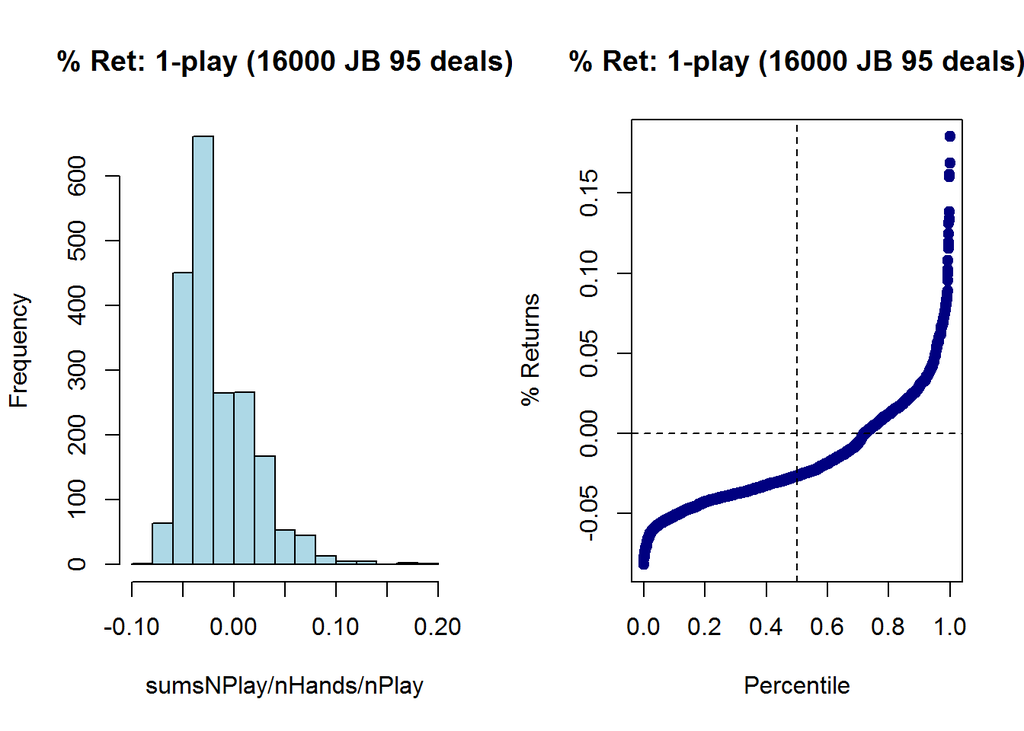

```
##
## Mean return per hand: 0.9844976 with total variance: 70.16407
## Mean return per hand: 98.424% with total variance (sd as % of total bet): 1,052,758 ( 2.14% )
##      1%      5%     10%     25%     50%     75%     90%     95%     99%
## -0.0550 -0.0465 -0.0414 -0.0311 -0.0178 -0.0033  0.0128  0.0242  0.0404
```

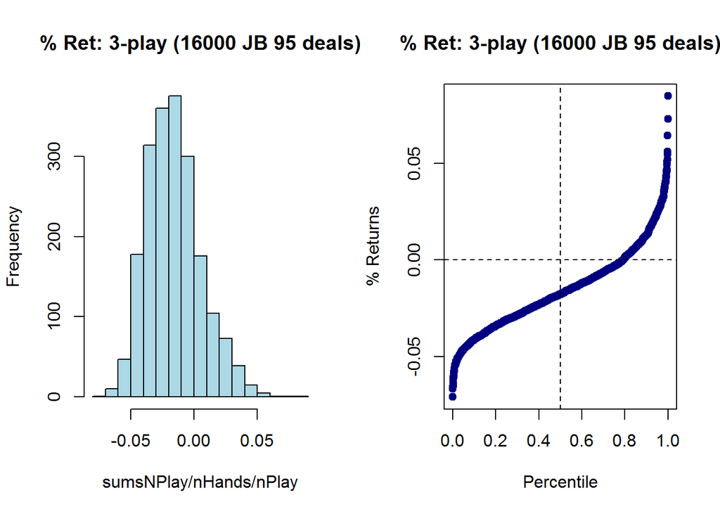

```
##
## Mean return per hand: 0.9844943 with total variance: 136.378
## Mean return per hand: 98.409% with total variance (sd as % of total bet): 2,183,810 ( 1.85% )
##      1%      5%     10%     25%     50%     75%     90%     95%     99%
## -0.0511 -0.0430 -0.0374 -0.0288 -0.0179 -0.0050  0.0074  0.0163  0.0373
```

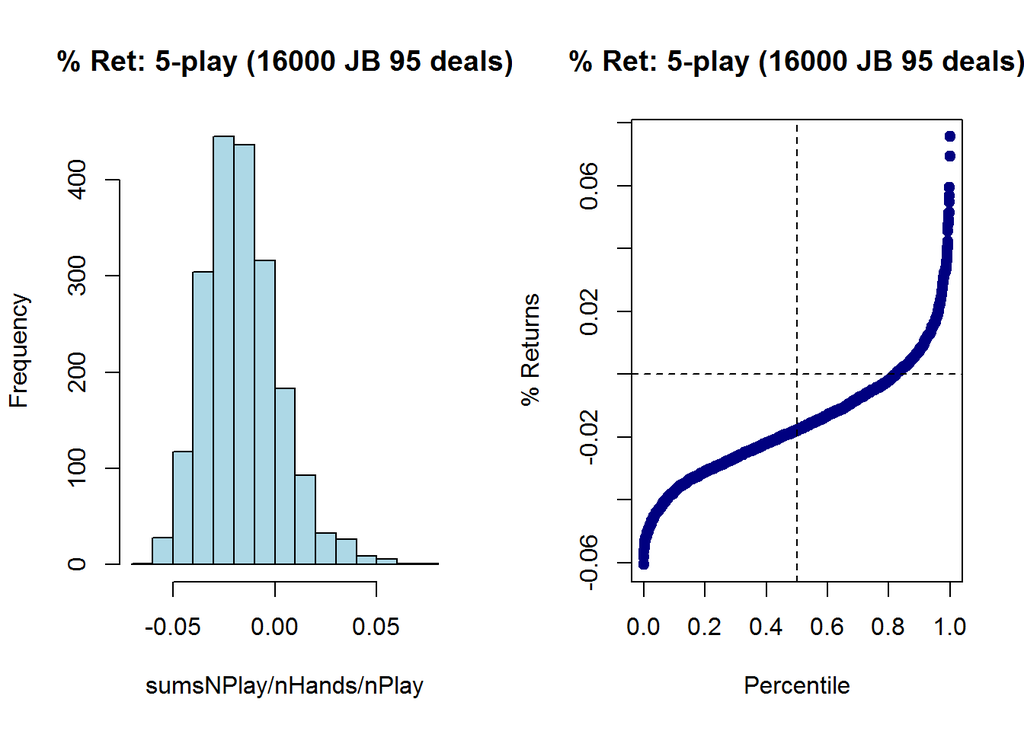

```
##
## Mean return per hand: 0.9844824 with total variance: 369.7508
## Mean return per hand: 98.446% with total variance (sd as % of total bet): 5,869,781 ( 1.51% )
##      1%      5%     10%     25%     50%     75%     90%     95%     99%
## -0.0438 -0.0370 -0.0327 -0.0258 -0.0169 -0.0077  0.0020  0.0097  0.0346
```

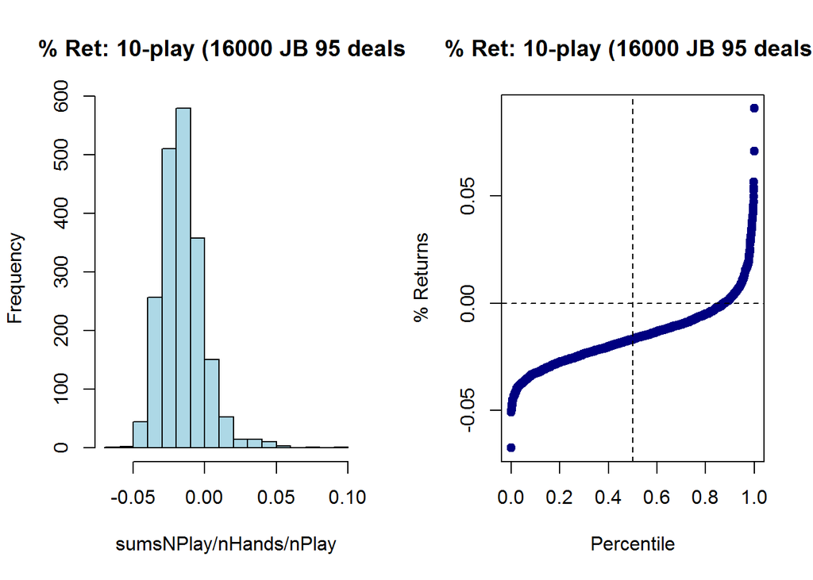

```
##
## Mean return per hand: 0.9844978 with total variance: 19.49537
## Mean return per hand: 98.401% with total variance (sd as % of total bet): 459,389 ( 2.82% )
##      1%      5%     10%     25%     50%     75%     90%     95%     99%
## -0.0608 -0.0518 -0.0470 -0.0380 -0.0215  0.0016  0.0228  0.0364  0.0644
```

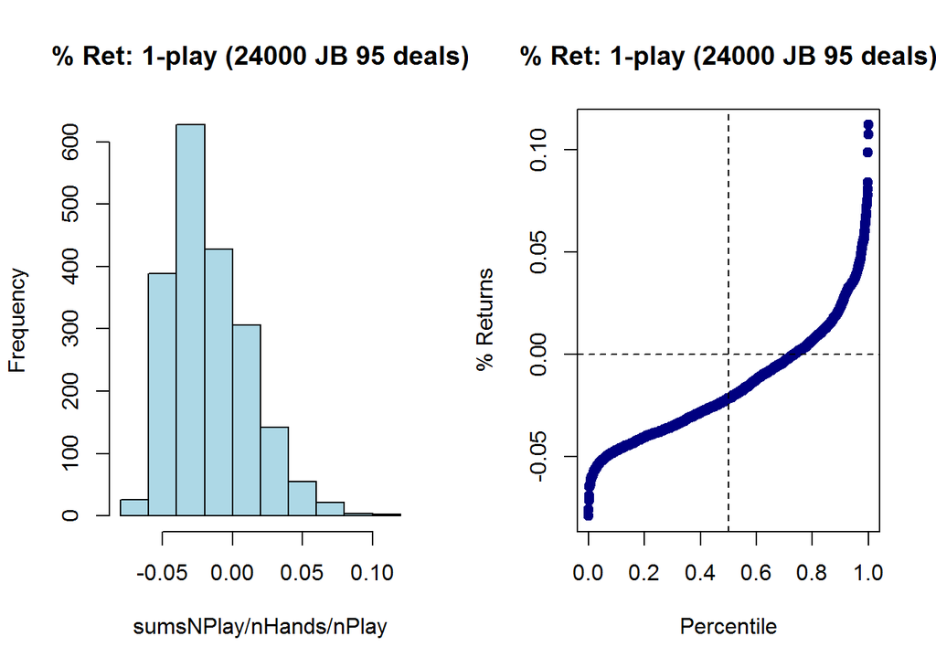

```
##
## Mean return per hand: 0.9844976 with total variance: 70.16407
## Mean return per hand: 98.527% with total variance (sd as % of total bet): 1,632,008 ( 1.77% )
##      1%      5%     10%     25%     50%     75%     90%     95%     99%
## -0.0482 -0.0412 -0.0365 -0.0276 -0.0159 -0.0040  0.0086  0.0163  0.0324
```

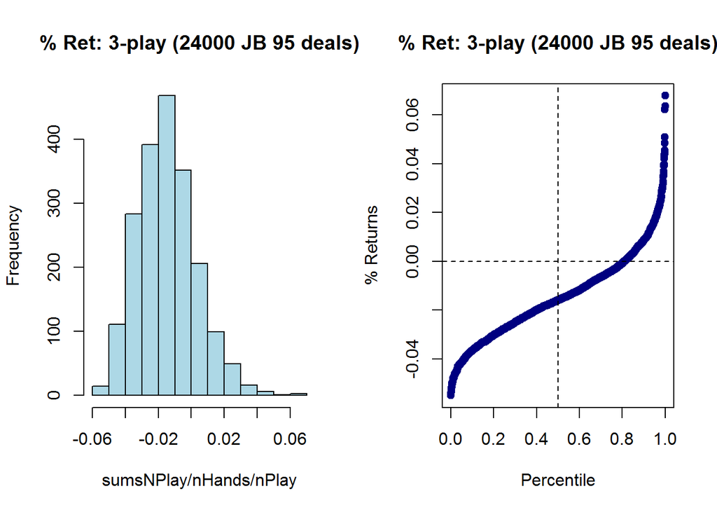

```
##
## Mean return per hand: 0.9844943 with total variance: 136.378
## Mean return per hand: 98.451% with total variance (sd as % of total bet): 3,150,257 ( 1.48% )
##      1%      5%     10%     25%     50%     75%     90%     95%     99%
## -0.0437 -0.0371 -0.0332 -0.0256 -0.0170 -0.0071  0.0036  0.0109  0.0276
```

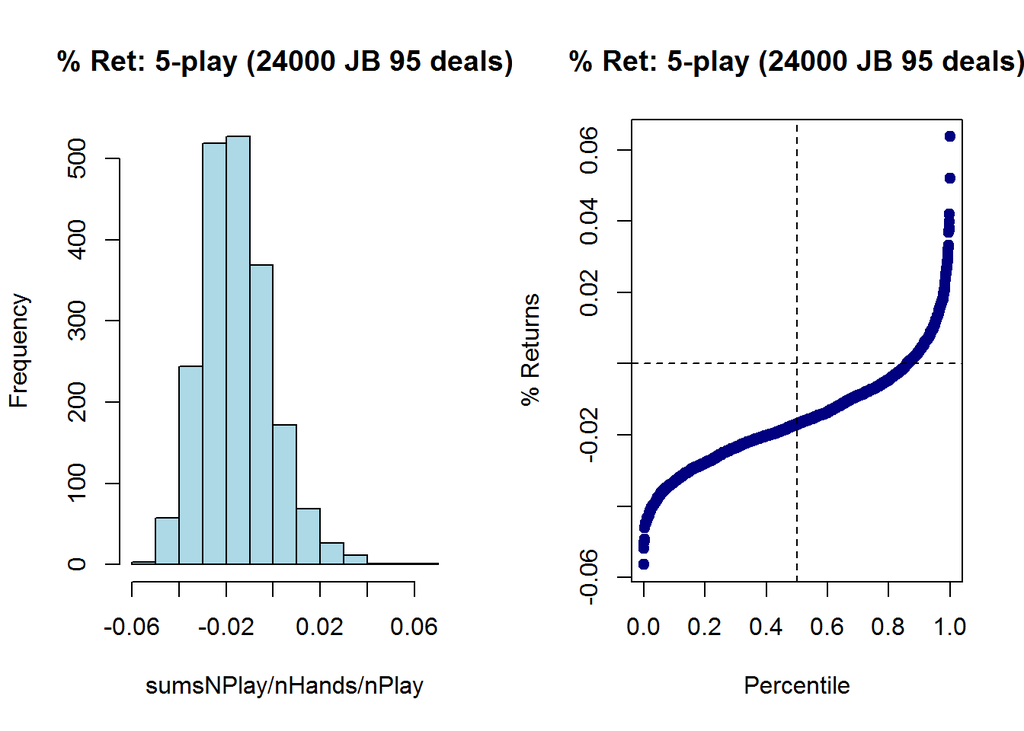

```
##
## Mean return per hand: 0.9844824 with total variance: 369.7508
## Mean return per hand: 98.422% with total variance (sd as % of total bet): 8,391,954 ( 1.21% )
##      1%      5%     10%     25%     50%     75%     90%     95%     99%
## -0.0389 -0.0332 -0.0301 -0.0239 -0.0167 -0.0091 -0.0003  0.0066  0.0197
```

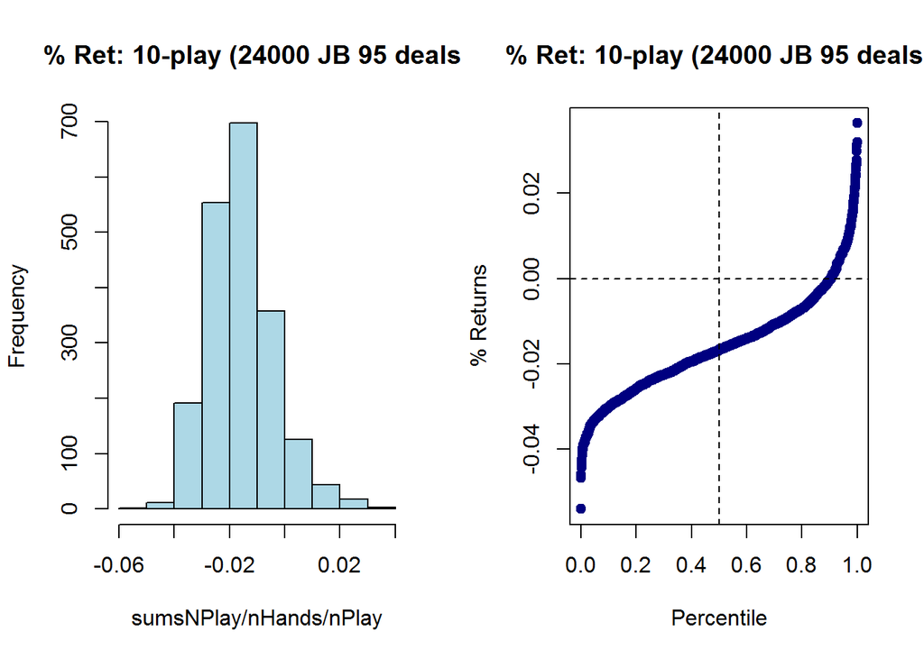

```
##
## Mean return per hand: 0.9844978 with total variance: 19.49537
## Mean return per hand: 98.433% with total variance (sd as % of total bet): 595,939 ( 2.41% )
##      1%      5%     10%     25%     50%     75%     90%     95%     99%
## -0.0555 -0.0487 -0.0437 -0.0339 -0.0189 -0.0017  0.0165  0.0295  0.0512
```

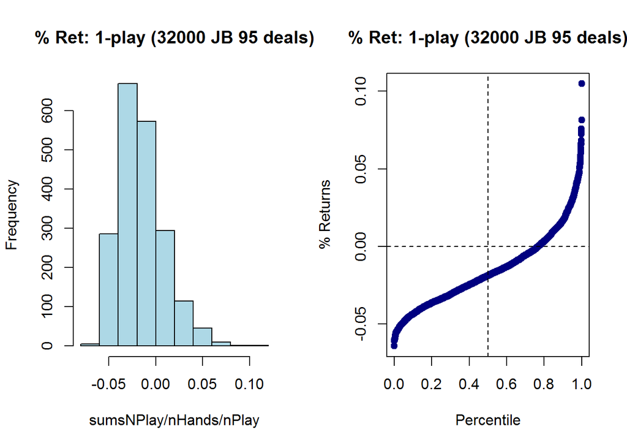

```
##
## Mean return per hand: 0.9844976 with total variance: 70.16407
## Mean return per hand: 98.454% with total variance (sd as % of total bet): 2,281,435 ( 1.57% )
##      1%      5%     10%     25%     50%     75%     90%     95%     99%
## -0.0460 -0.0381 -0.0347 -0.0268 -0.0171 -0.0055  0.0055  0.0128  0.0268
```

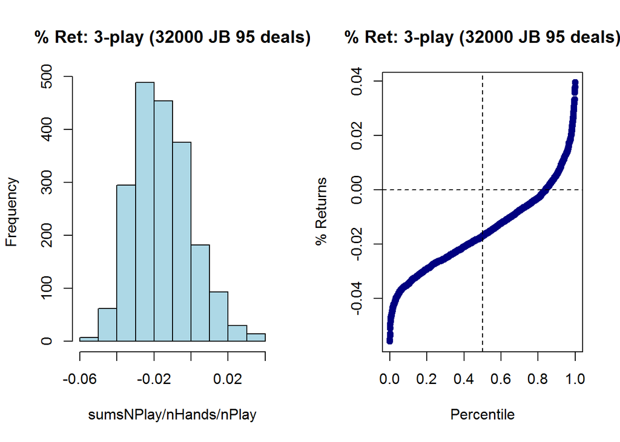

```
##
## Mean return per hand: 0.9844943 with total variance: 136.378
## Mean return per hand: 98.426% with total variance (sd as % of total bet): 4,381,736 ( 1.31% )
##      1%      5%     10%     25%     50%     75%     90%     95%     99%
## -0.0412 -0.0343 -0.0312 -0.0250 -0.0168 -0.0082  0.0009  0.0083  0.0205
```

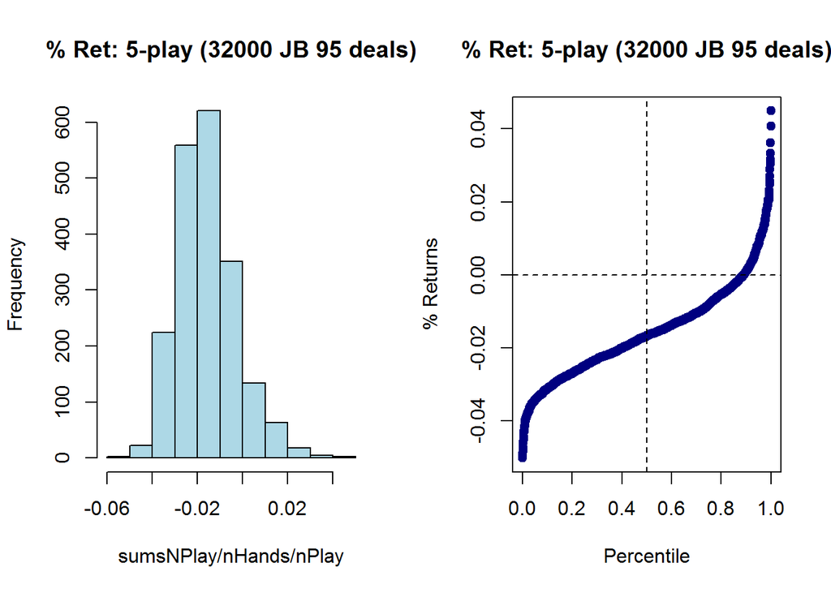

```
##
## Mean return per hand: 0.9844824 with total variance: 369.7508
## Mean return per hand: 98.446% with total variance (sd as % of total bet): 11,943,912 ( 1.08% )
##      1%      5%     10%     25%     50%     75%     90%     95%     99%
## -0.0360 -0.0313 -0.0284 -0.0229 -0.0164 -0.0097 -0.0021  0.0042  0.0166
```

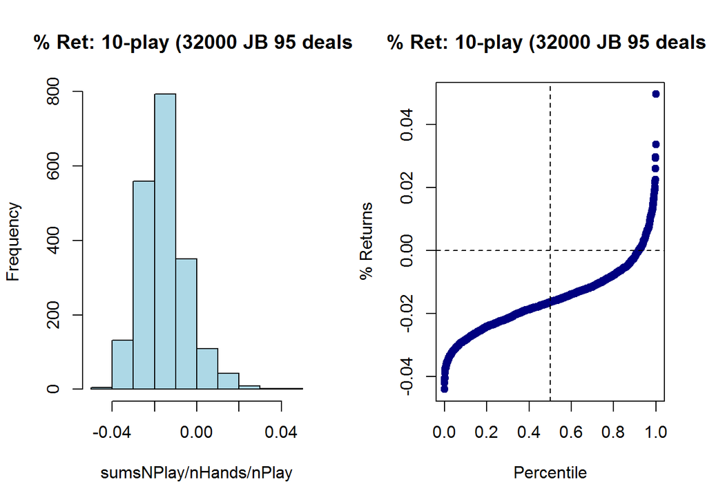

```
##
## Mean return per hand: 0.9844978 with total variance: 19.49537
## Mean return per hand: 98.438% with total variance (sd as % of total bet): 795,924 ( 2.23% )
##      1%      5%     10%     25%     50%     75%     90%     95%     99%
## -0.0543 -0.0465 -0.0416 -0.0327 -0.0181 -0.0026  0.0148  0.0261  0.0488
```

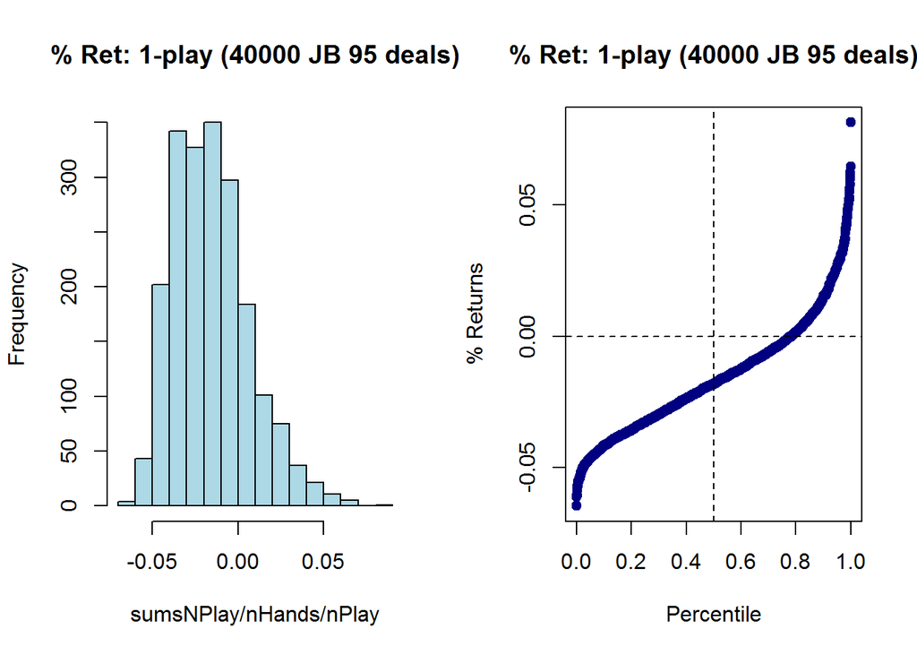

```
##
## Mean return per hand: 0.9844976 with total variance: 70.16407
## Mean return per hand: 98.49% with total variance (sd as % of total bet): 2,861,287 ( 1.41% )
##      1%      5%     10%     25%     50%     75%     90%     95%     99%
## -0.0432 -0.0363 -0.0325 -0.0249 -0.0158 -0.0067  0.0031  0.0105  0.0243
```

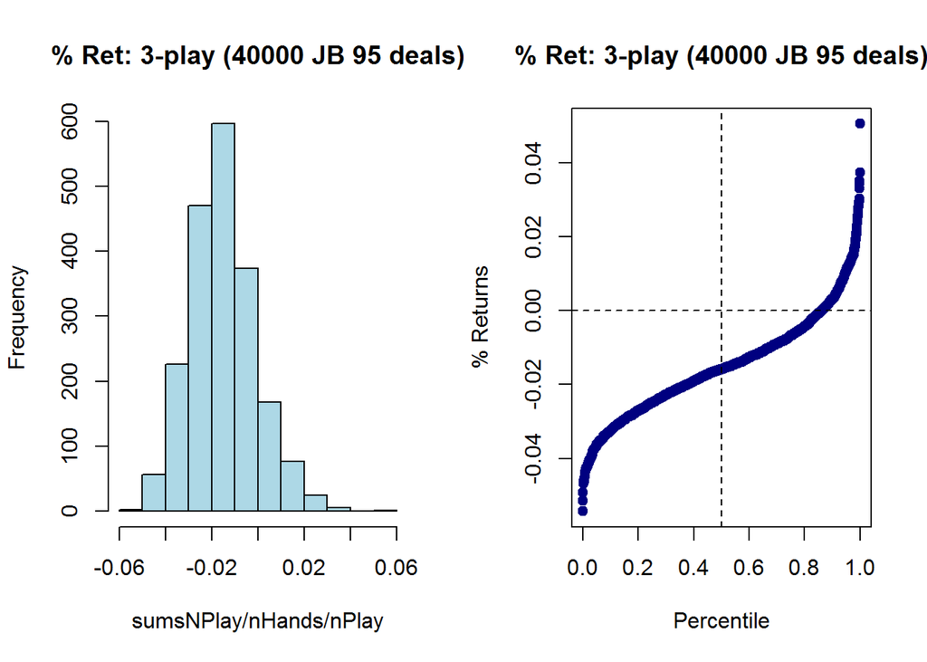

```
##
## Mean return per hand: 0.9844943 with total variance: 136.378
## Mean return per hand: 98.416% with total variance (sd as % of total bet): 5,304,323 ( 1.15% )
##      1%      5%     10%     25%     50%     75%     90%     95%     99%
## -0.0395 -0.0330 -0.0299 -0.0242 -0.0165 -0.0090 -0.0009  0.0042  0.0154
```

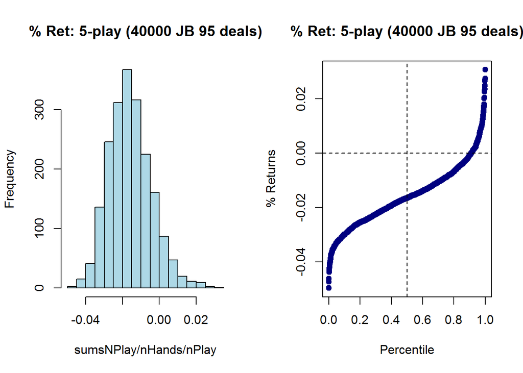

```
##
## Mean return per hand: 0.9844824 with total variance: 369.7508
## Mean return per hand: 98.472% with total variance (sd as % of total bet): 15,679,689 ( 0.99% )
##      1%      5%     10%     25%     50%     75%     90%     95%     99%
## -0.0344 -0.0296 -0.0267 -0.0218 -0.0161 -0.0102 -0.0034  0.0025  0.0146
```

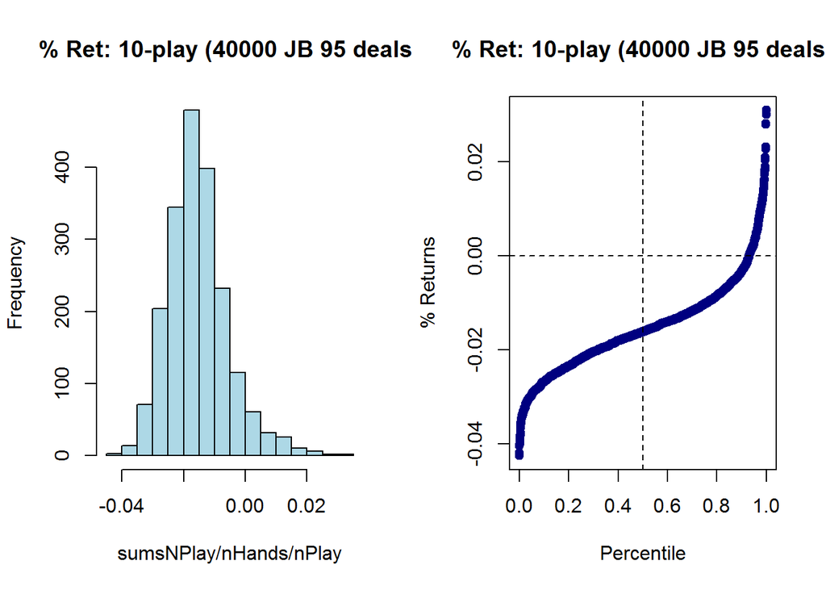

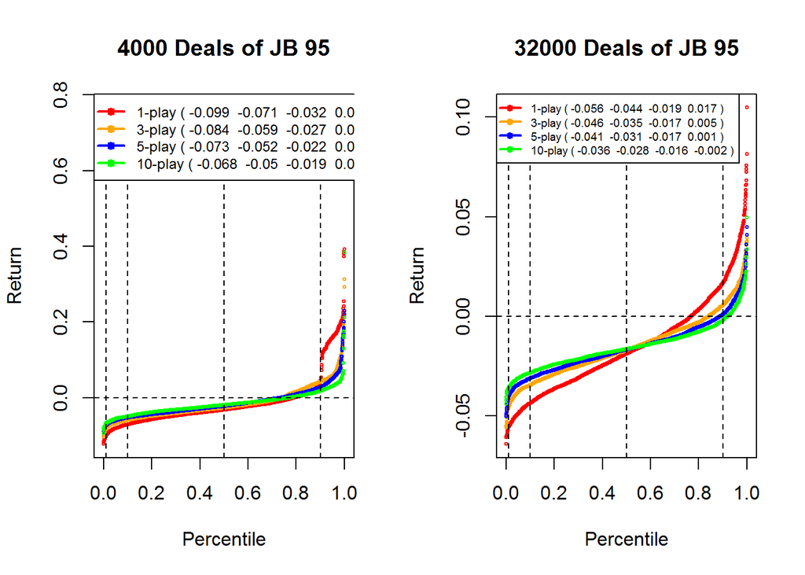

```r
simPct <- apply(simOut, 1, FUN=function(x) { c(x[1], x[2], sort(x[-(1:2)]/x[1]/x[2])) } )

par(mfcol=c(1, 2))

plot(x=(1:nSims)/nSims, y=simPct[-(1:2), 9], col="red", cex=0.4,
     xlab="Percentile", ylab="Return", main="4000 Deals of JB 95"
     )
points(x=(1:nSims)/nSims, y=simPct[-(1:2), 10], col="orange", cex=0.4)
points(x=(1:nSims)/nSims, y=simPct[-(1:2), 11], col="blue", cex=0.4)
points(x=(1:nSims)/nSims, y=simPct[-(1:2), 12], col="green", cex=0.4)
abline(h=0, v=c(0.01, 0.1, 0.5, 0.9), lty=2)
quan01 <- quantile(simPct[-(1:2), 9], c(0.01, 0.1, 0.5, 0.9))
quan03 <- quantile(simPct[-(1:2), 10], c(0.01, 0.1, 0.5, 0.9))
quan05 <- quantile(simPct[-(1:2), 11], c(0.01, 0.1, 0.5, 0.9))
quan10 <- quantile(simPct[-(1:2), 12], c(0.01, 0.1, 0.5, 0.9))
legend("topleft",
       legend=c(paste0("1-play ( ", paste(round(quan01, 3), collapse="  "), " )"),
                paste0("3-play ( ", paste(round(quan03, 3), collapse="  "), " )"),
                paste0("5-play ( ", paste(round(quan05, 3), collapse="  "), " )"),
                paste0("10-play ( ", paste(round(quan10, 3), collapse="  "), " )")
                ),
       col=c("red", "orange", "blue", "green"), lwd=2, pch=19, cex=0.75
       )

plot(x=(1:nSims)/nSims, y=simPct[-(1:2), 25], col="red", cex=0.4,
     xlab="Percentile", ylab="Return", main="32000 Deals of JB 95"
     )
points(x=(1:nSims)/nSims, y=simPct[-(1:2), 26], col="orange", cex=0.4)
points(x=(1:nSims)/nSims, y=simPct[-(1:2), 27], col="blue", cex=0.4)
points(x=(1:nSims)/nSims, y=simPct[-(1:2), 28], col="green", cex=0.4)
abline(h=0, v=c(0.01, 0.1, 0.5, 0.9), lty=2)
quan01 <- quantile(simPct[-(1:2), 25], c(0.01, 0.1, 0.5, 0.9))
quan03 <- quantile(simPct[-(1:2), 26], c(0.01, 0.1, 0.5, 0.9))
quan05 <- quantile(simPct[-(1:2), 27], c(0.01, 0.1, 0.5, 0.9))
quan10 <- quantile(simPct[-(1:2), 28], c(0.01, 0.1, 0.5, 0.9))
legend("topleft",
       legend=c(paste0("1-play ( ", paste(round(quan01, 3), collapse="  "), " )"),
                paste0("3-play ( ", paste(round(quan03, 3), collapse="  "), " )"),
                paste0("5-play ( ", paste(round(quan05, 3), collapse="  "), " )"),
                paste0("10-play ( ", paste(round(quan10, 3), collapse="  "), " )")
                ),
       col=c("red", "orange", "blue", "green"), lwd=2, pch=19, cex=0.6
       )
```

```r
par(mfcol=c(1, 1))
```